# ConservationAnalysisReport

Jebriel Abdul

June 15, 2021

Preceding work for the conservation analysis is omitted aside from histograms plotting window’s scores and percent scores. Here I attempt to define some characteristics of highly conserved R-loops and distinguish them from those which are not..

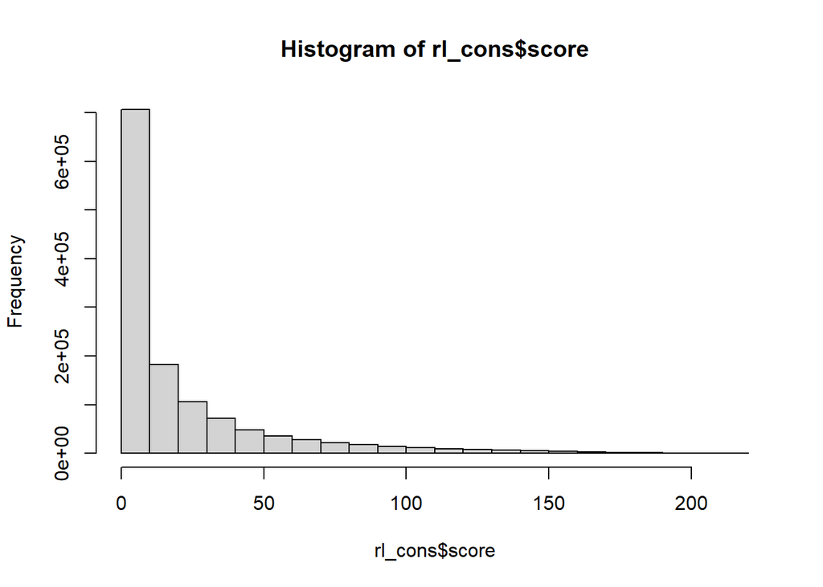

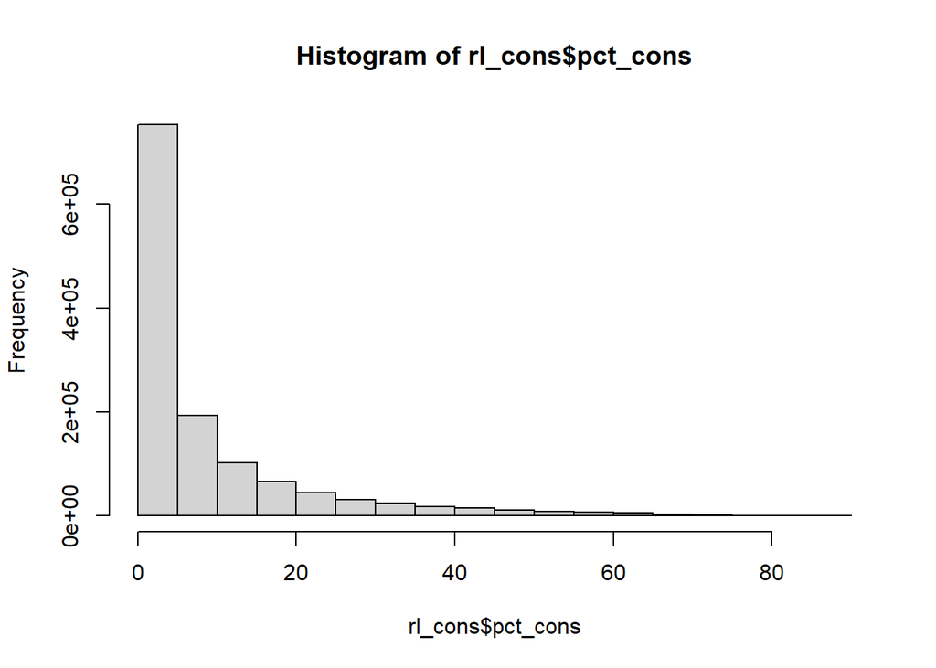

```
## GRanges object with 12 ranges and 2 metadata columns:
##                  seqnames              ranges strand |     score  pct_cons
##                     <Rle>           <IRanges>  <Rle> | <numeric> <numeric>
##    window_758542    chr11   65415000-65425000      * |       219   86.9048
##    window_758543    chr11   65417500-65427500      * |       218   86.5079
##    window_758544    chr11   65420000-65430000      * |       218   86.5079
##    window_758545    chr11   65422500-65432500      * |       217   86.1111
##    window_758573    chr11   65492500-65502500      * |       220   87.3016
##              ...      ...                 ...    ... .       ...       ...
##    window_827261    chr10 102125000-102135000      * |       217   86.1111
##    window_842706    chr12     6940000-6950000      * |       217   86.1111
##    window_889895    chr12 124912500-124922500      * |       217   86.1111
##   window_1089166    chr17   76070000-76080000      * |       217   86.1111
##   window_1166796    chr19   42067500-42077500      * |       218   86.5079
##   -------
##   seqinfo: 455 sequences from an unspecified genome; no seqlengths
```

### Metaplot Analysis

I start by creating metaplots for three different groups of windows: the whole set, windows with a percent score greater than 60 and the 12 highest percent scoring windows.

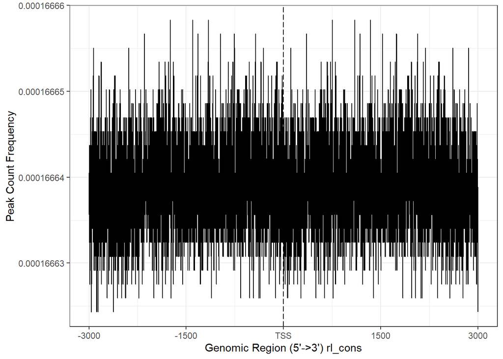

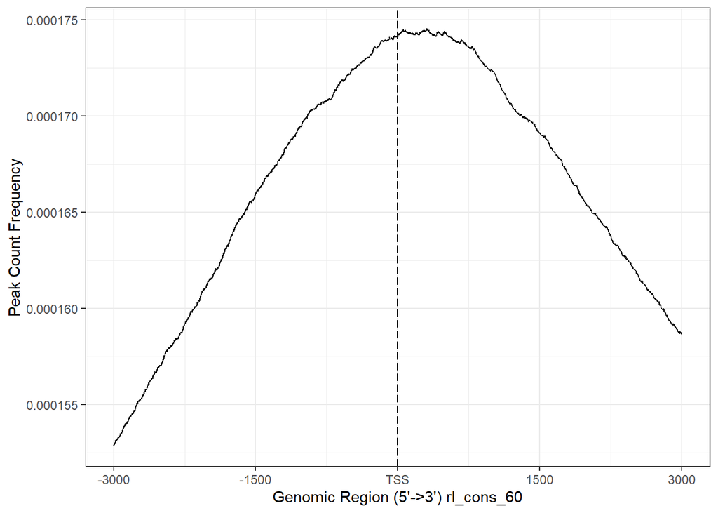

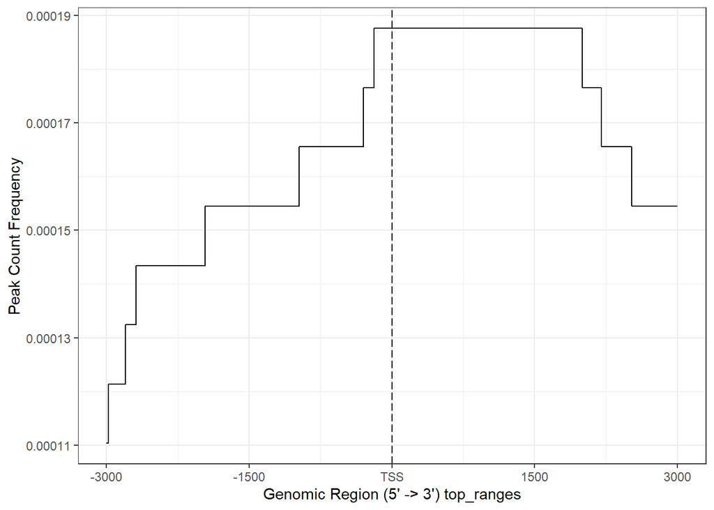

```r
#preparing annotations
library(TxDb.Hsapiens.UCSC.hg38.knownGene)
txdb <- TxDb.Hsapiens.UCSC.hg38.knownGene
promoter <- getPromoters(TxDb=txdb, upstream=3000, downstream=3000)

#preparing rl_cons_60; windows with having more than 60 percent of Rloops aligned to it
limit <- 60
rl_cons_60 <- rl_cons[which(rl_cons$pct_cons >limit)]

tagMatrix_rl_cons <- getTagMatrix(rl_cons, windows = promoter)
tagMatrix_rl_cons_60 <- getTagMatrix(rl_cons_60,windows = promoter)
tagMatrix_top_ranges <- getTagMatrix(rl_cons[top_ranges], windows = promoter)

#creating metaplots for the three groups above
plotAvgProf(tagMatrix_rl_cons, xlim=c(-3000, 3000), xlab="Genomic Region (5'->3') rl_cons")
plotAvgProf(tagMatrix_rl_cons_60, xlim=c(-3000,3000), xlab = "Genomic Region (5'->3') rl_cons_60")
plotAvgProf(tagMatrix_top_ranges,xlim = c(-3000,3000), xlab = "Genomic Region (5' -> 3') top_ranges")
cat("\n")
```

The metaplot for all peaks produces a very noisy plot and so there is no useful information we could take from it. This should have been expected. The other two metaplots are more like those which we might see when analyzing protien coding genes (like NFE2L2 or BCRA1). However, the peaks are more normally distributed around the TSS and produce a curve which is “flatter” than what a protien coding gene might produce.

After transcription, if the nascent RNA had been modified, (ie. spliced, capped and tailed), the anealing of the RNA to the DNA template would displace regions which had previously coded the premature RNA’s exons. These displaced regions form loops which are known as R-loops[1].

R loops will form across the whole length of a gene being transcribed, and so peaks will align at windows close to a TSS, but in surrounding regions aswell since thes DNA template for these genes may span at least thousands of base pairs. This explains the “flatter” curve presented by the metaplots of rl_cons_60 and the top 12 ranges.

Knowing this, I would expect the see groups of windows with higher percent scores present increasingly flat curves - if more peaks align to the higher scoring windows, then there should be more peaks which are further upstream from the TSS. Windows with lower percent scores would produce curves which are just noise, as in the first meta plot.

```
## [1] 10.31746
```

```
## [1] 20.2381
```

```
## [1] 30.15873
```

```
## [1] 40.07937
```

```
## [1] 50.39683
```

```
## [1] 60.31746
```

```
## [1] 70.2381
```

```
## [1] 80.15873
```

```
## $`2`
## [1] 10.31746
##
## $`3`
## [1] 20.2381
##
## $`4`
## [1] 30.15873
##
## $`5`
## [1] 40.07937
##
## $`6`
## [1] 50.39683
##
## $`7`
## [1] 60.31746
##
## $`8`
## [1] 70.2381
##
## $`9`
## [1] 80.15873
```

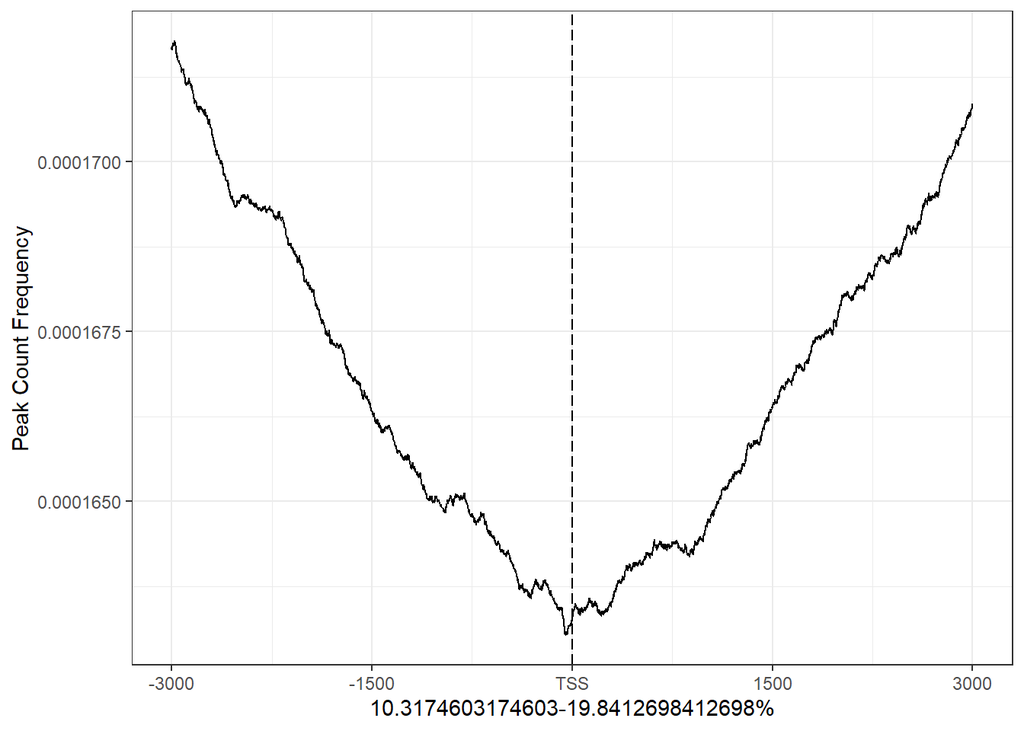

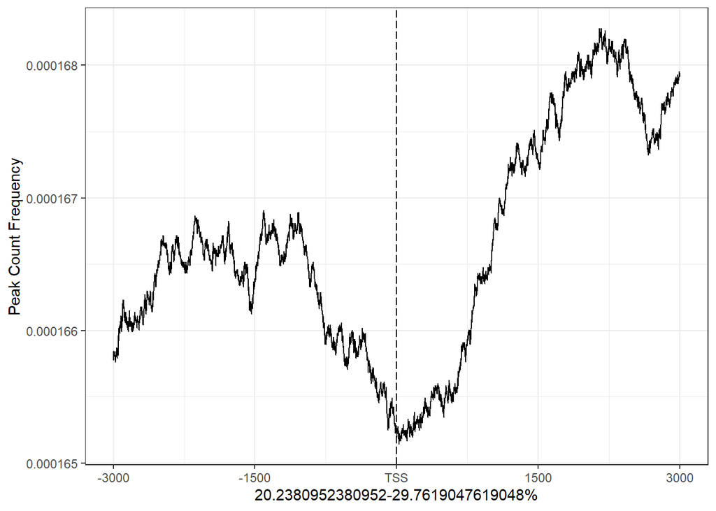

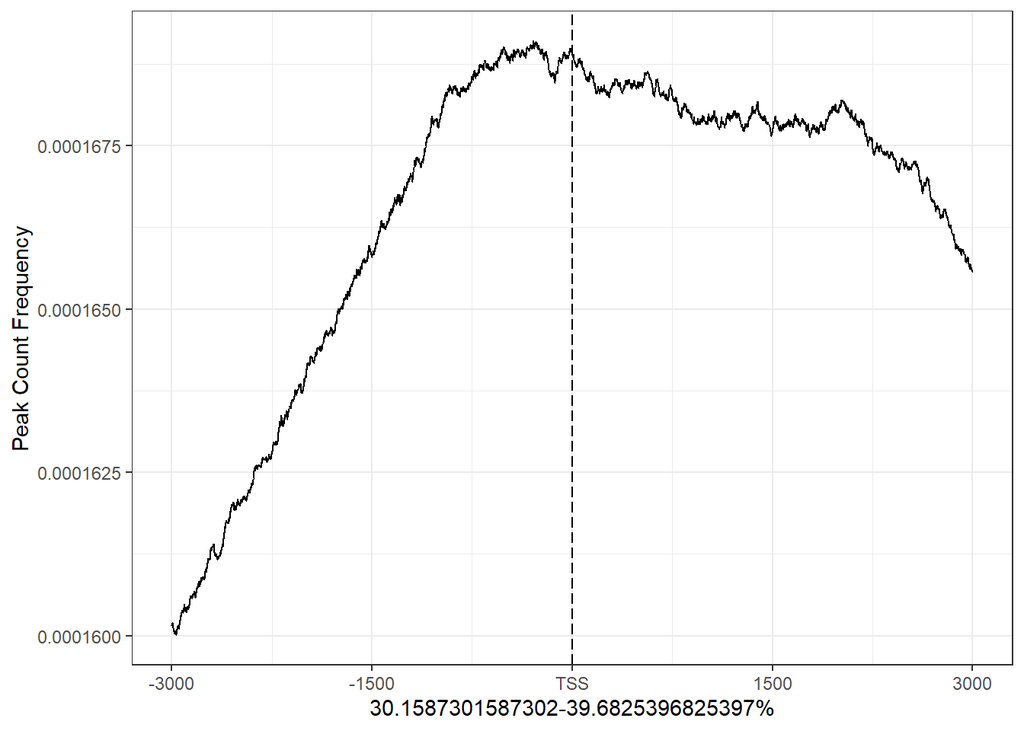

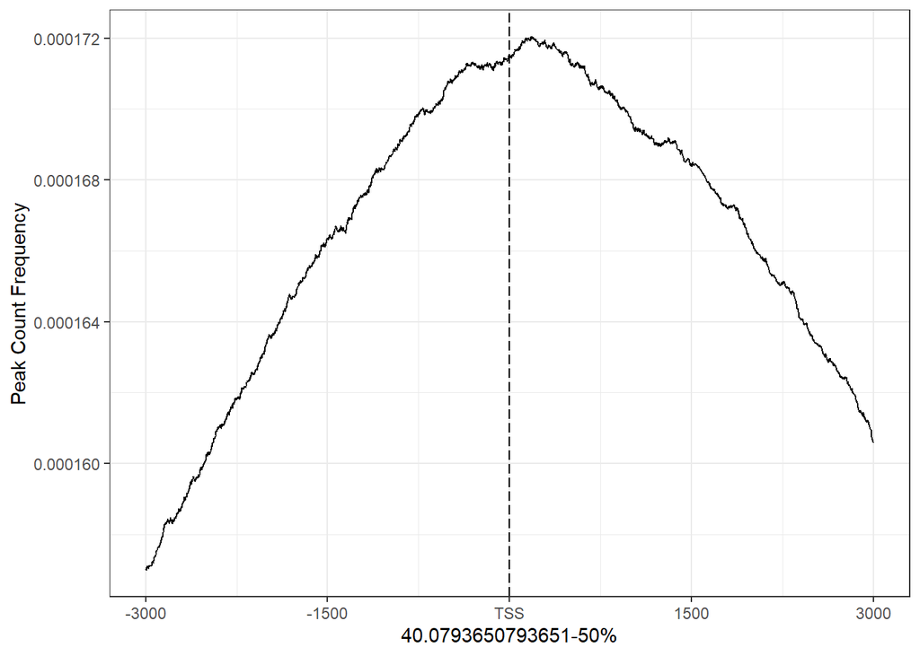

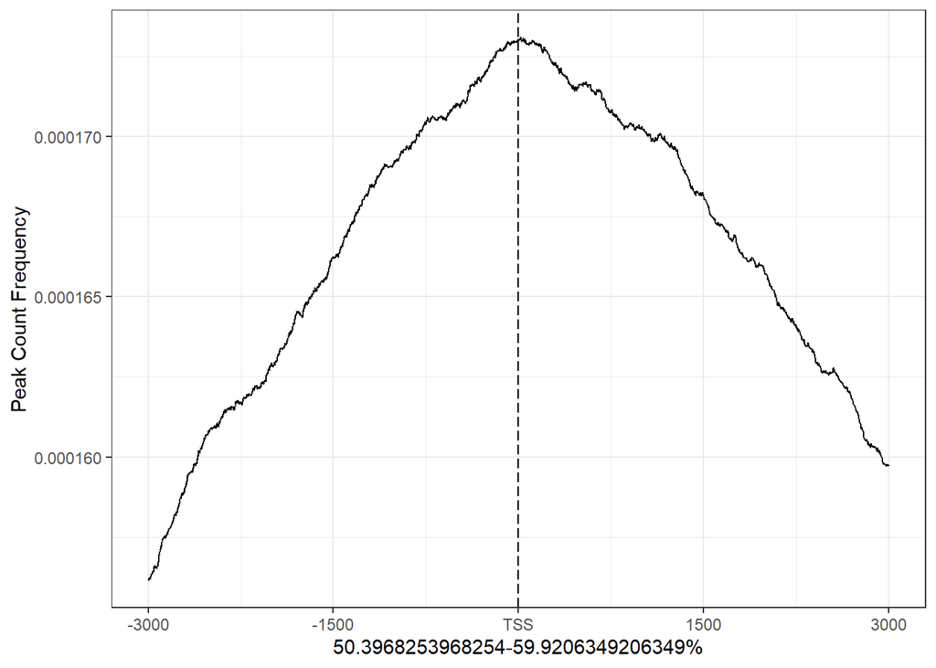

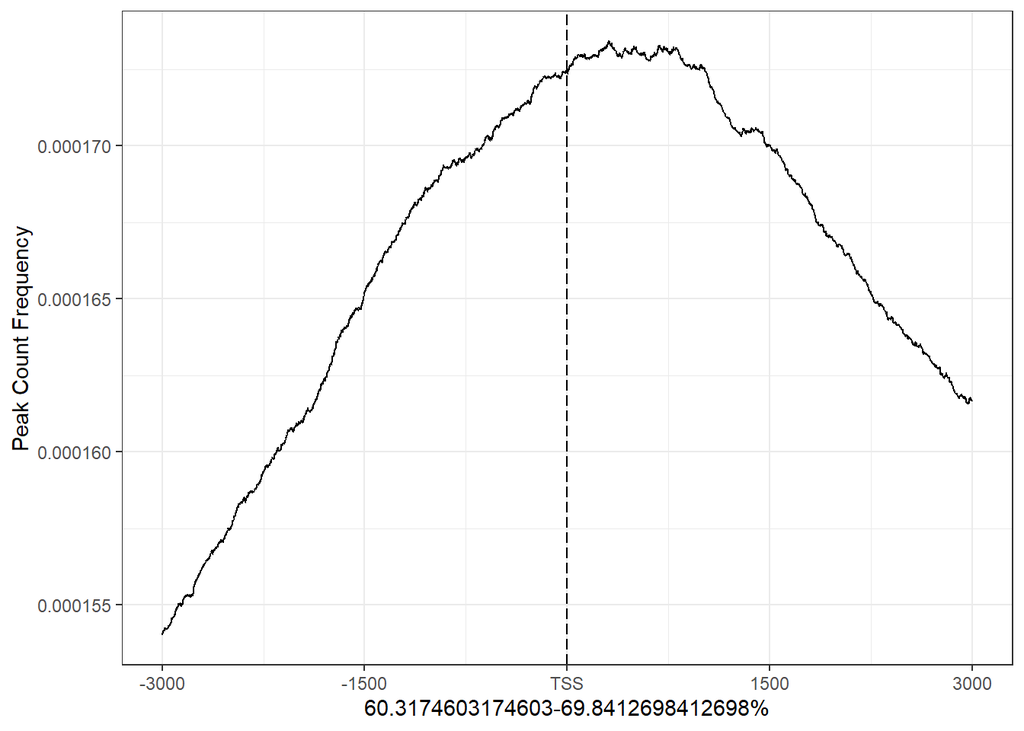

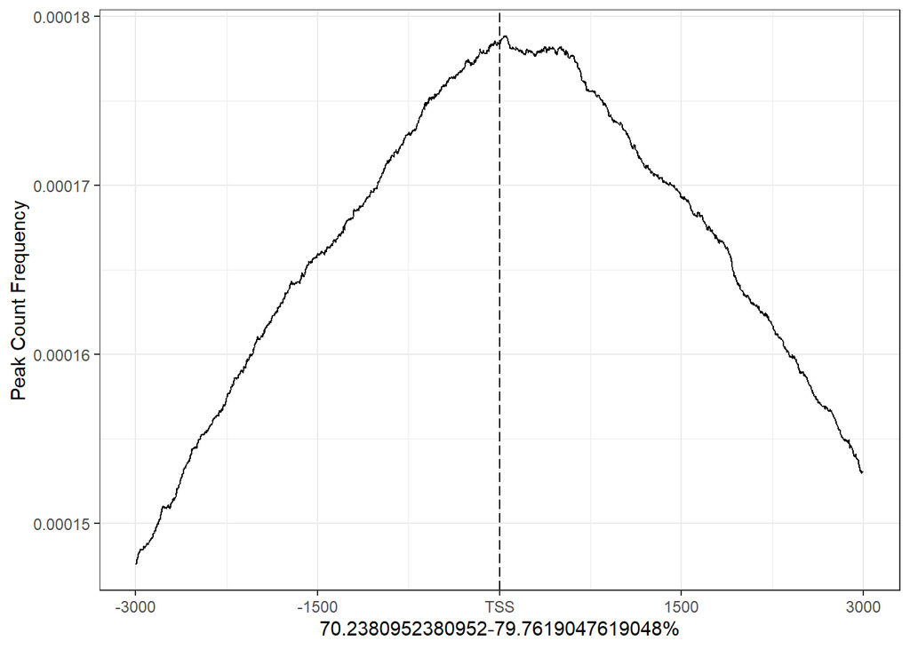

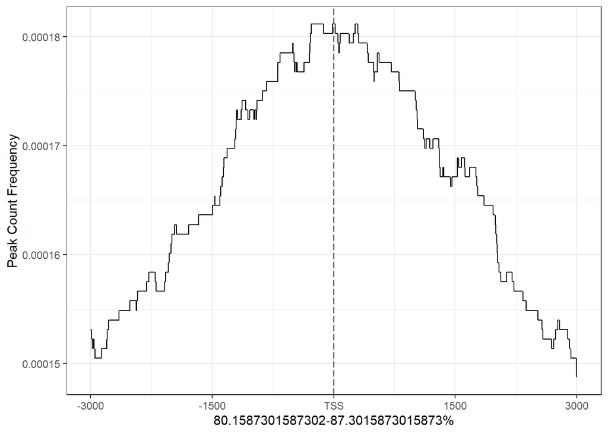

X labels describe the range of percent score of each plot.

Following this, the whole set of windows were ranked in ascending order of percent score, then split into 10 groups, each with an equal number of windows. Metaplots were then generated from these new groups.

```
## [1] 10.31746
```

```
## [1] 11.50794
```

```
## [1] 13.09524
```

```
## [1] 14.68254
```

```
## [1] 17.06349
```

```
## [1] 20.2381
```

```
## [1] 23.80952
```

```
## [1] 28.96825
```

```
## [1] 35.71429
```

```
## [1] 46.8254
```

```
## $`1`
## [1] 10.31746
##
## $`2`
## [1] 11.50794
##
## $`3`
## [1] 13.09524
##
## $`4`
## [1] 14.68254
##
## $`5`
## [1] 17.06349
##
## $`6`
## [1] 20.2381
##
## $`7`
## [1] 23.80952
##
## $`8`
## [1] 28.96825
##
## $`9`
## [1] 35.71429
##
## $`10`
## [1] 46.8254
```

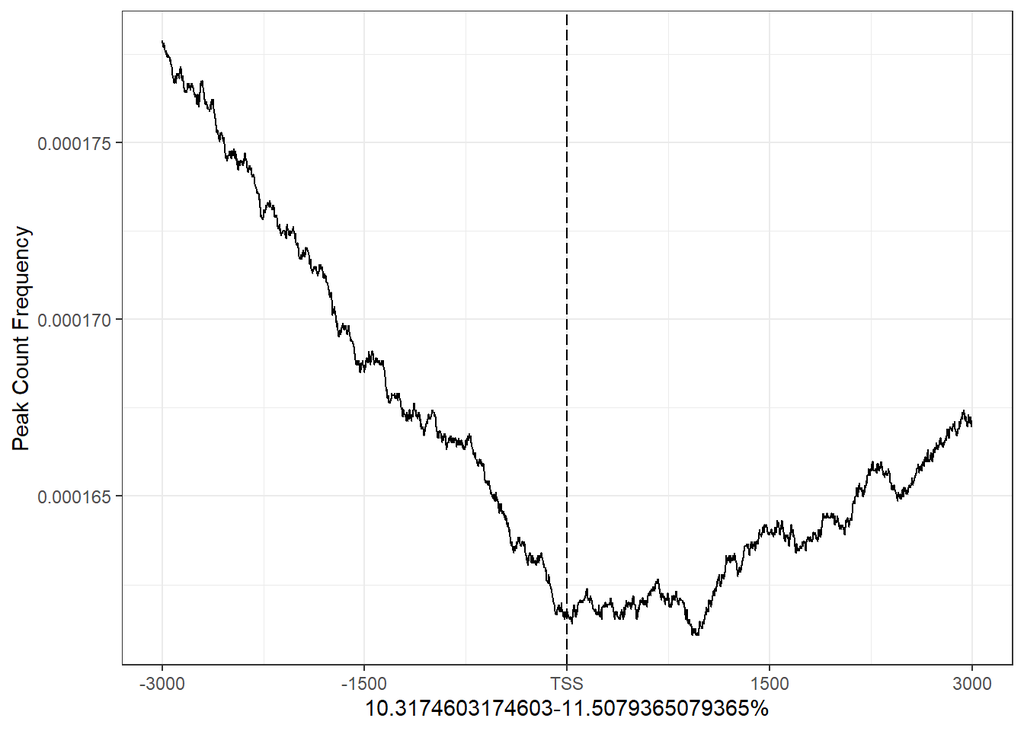

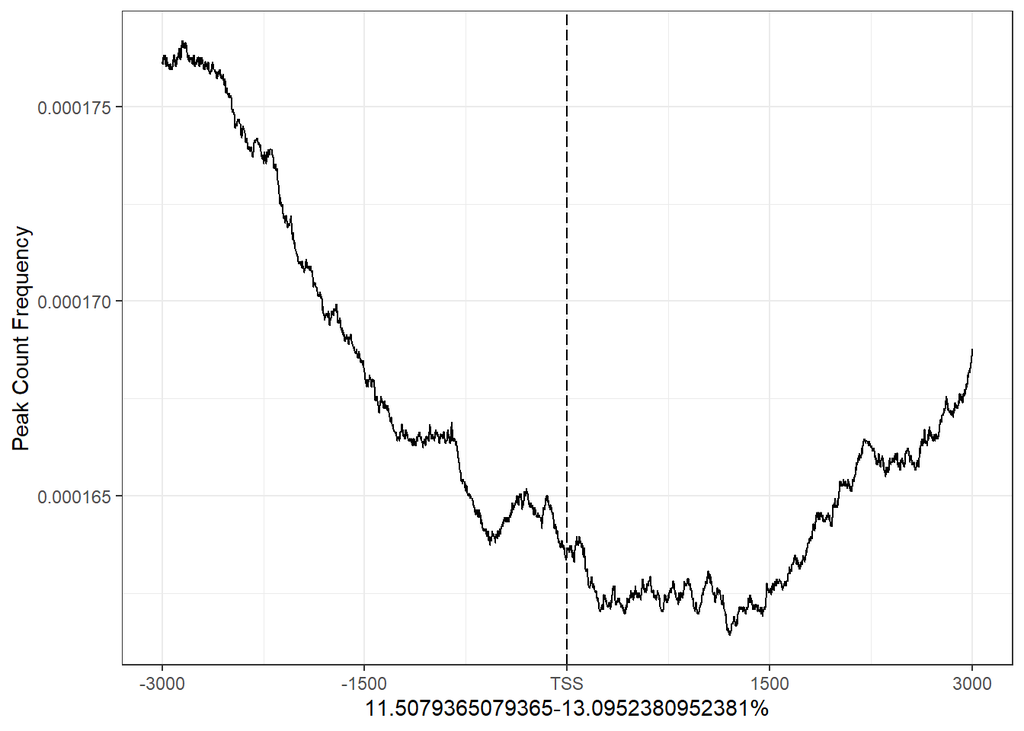

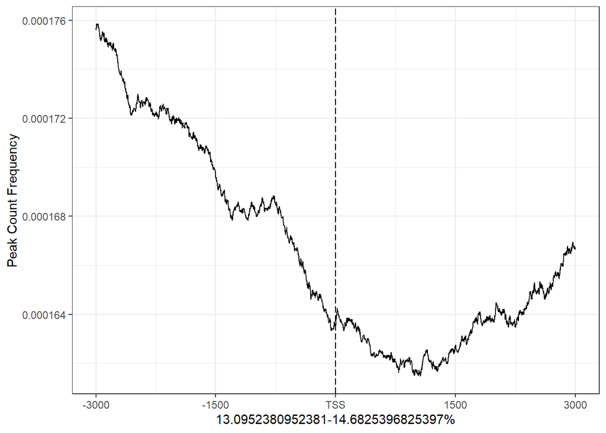

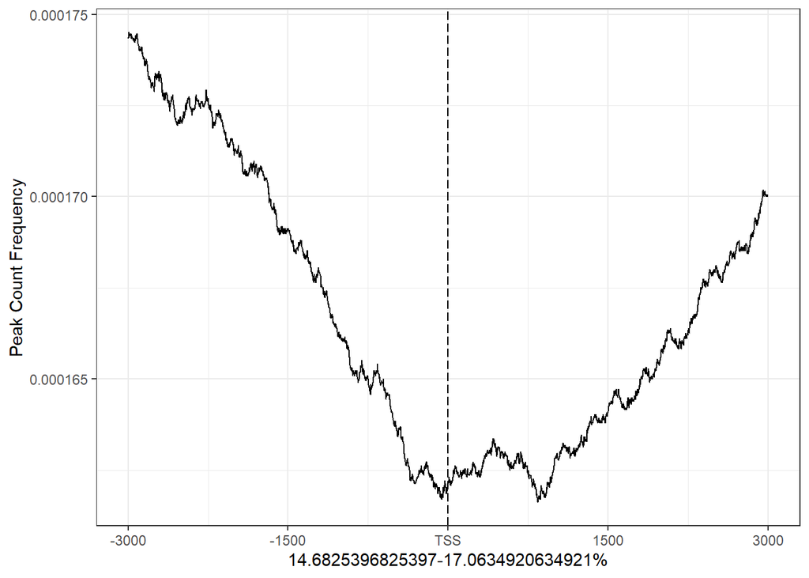

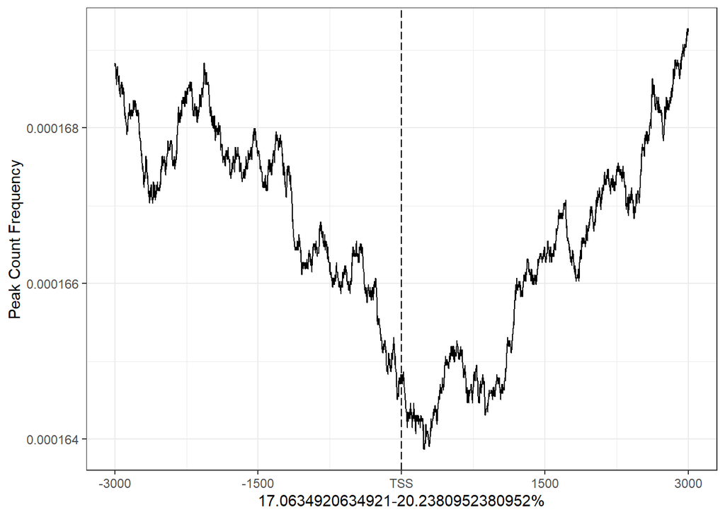

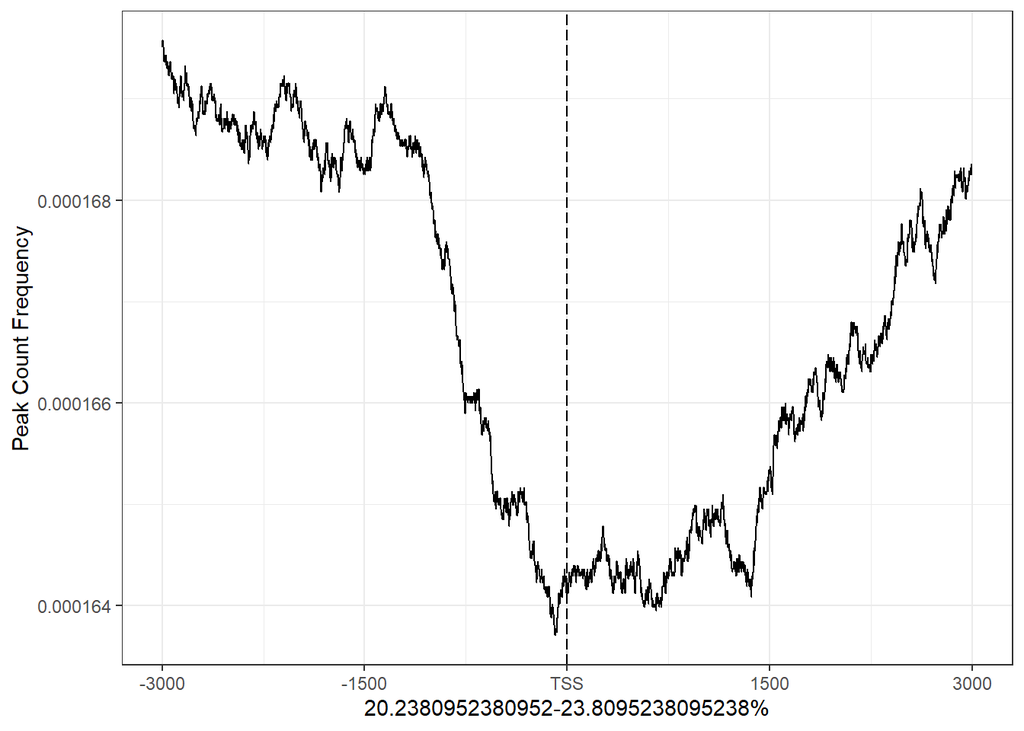

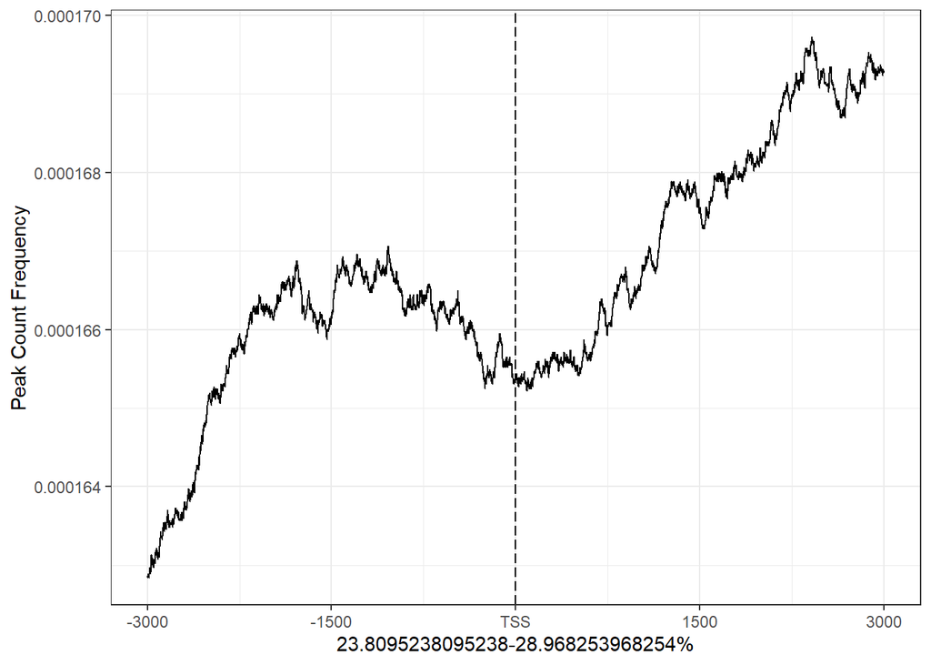

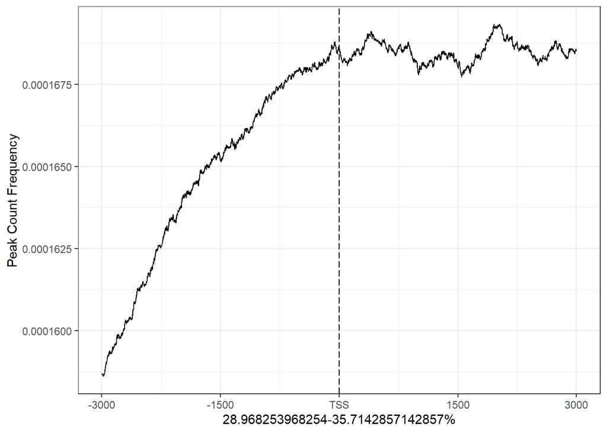

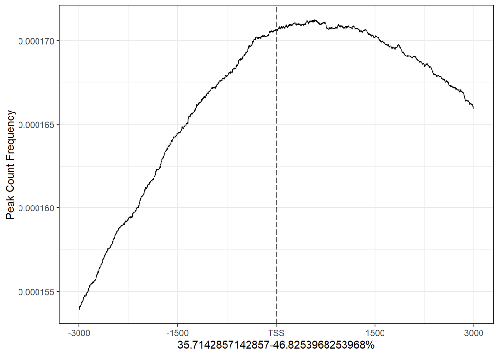

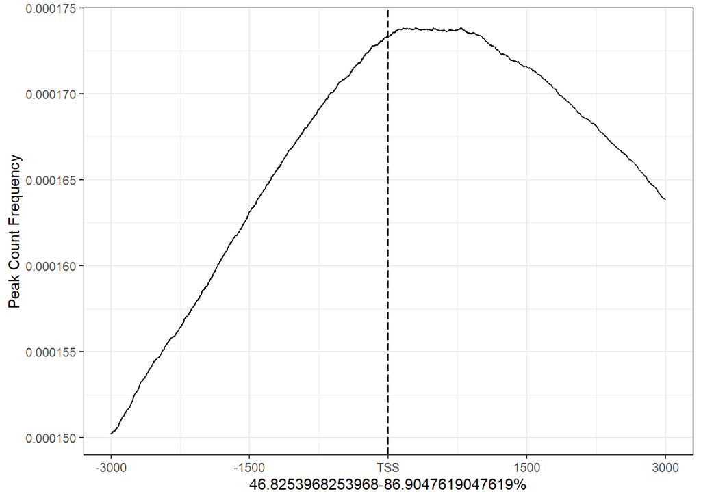

The same trend shown by the first group of metaplots is true for the transformed data as well; lower percent scoring windows tend to be further from the TSS compared to higher percenting scoring windows. However, a large portion of the wohle set of windows are located hundreds of basepairs from a TSS. This raises the question of whether this large portion of windows, as well as the whole set of windows, are located near r-loop forming regions(RLFRs). And given that - unlike lower percent scoring windows - higher percent scoring windows tend to be close to a TSS, could there exist a decrepency between higher and lower scoring windows in their relationship to RLFRs.

The explore this question, a permutation test over rl_cons is run against a region set describing r-loop forming regions. This was done first on the whole set of windows,

```
## $mfrow
## [1] 1 1
##
## $`regioneR::numOverlaps`
## P-value: 0.00662251655629139
## Z-score: 20.7473
## Number of iterations: 150
## Alternative: greater
## Evaluation of the original region set: 482220
## Evaluation function: regioneR::numOverlaps
## Randomization function: regioneR::circularRandomizeRegions
##
## attr(,"class")
## [1] "permTestResultsList"
```

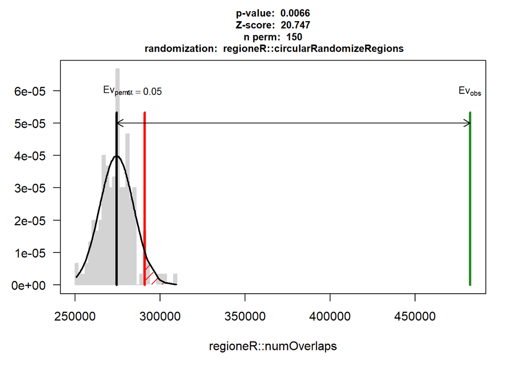

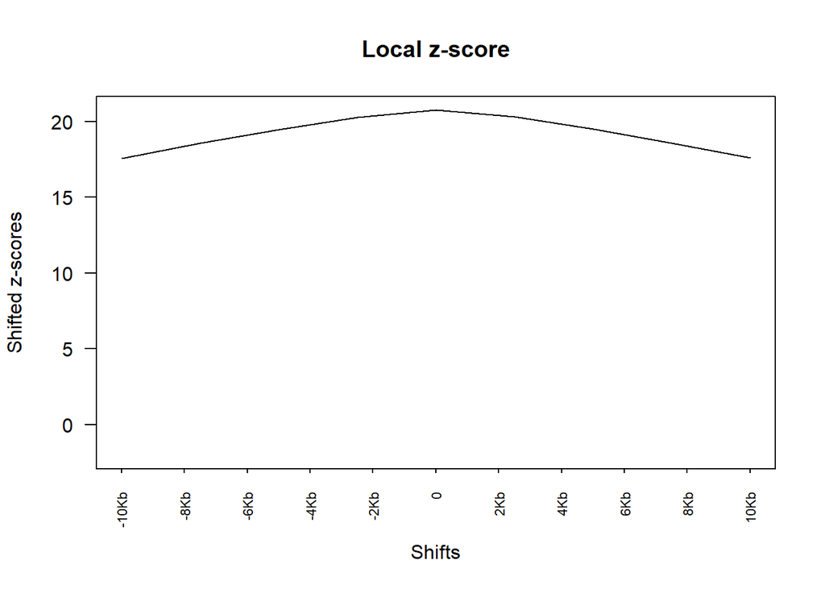

as well as each tenth.

```
## $mfrow
## [1] 1 1
##
## $`regioneR::numOverlaps`
## P-value: 0.00662251655629139
## Z-score: 4.9026
## Number of iterations: 150
## Alternative: greater
## Evaluation of the original region set: 27314
## Evaluation function: regioneR::numOverlaps
## Randomization function: regioneR::circularRandomizeRegions
##
## attr(,"class")
## [1] "permTestResultsList"
```

```
## $mfrow
## [1] 1 1
##
## $`regioneR::numOverlaps`
## P-value: 0.00662251655629139
## Z-score: 5.6251
## Number of iterations: 150
## Alternative: greater
## Evaluation of the original region set: 29546
## Evaluation function: regioneR::numOverlaps
## Randomization function: regioneR::circularRandomizeRegions
##
## attr(,"class")
## [1] "permTestResultsList"
```

```
## $mfrow
## [1] 1 1
##
## $`regioneR::numOverlaps`
## P-value: 0.00662251655629139
## Z-score: 8.0162
## Number of iterations: 150
## Alternative: greater
## Evaluation of the original region set: 31253
## Evaluation function: regioneR::numOverlaps
## Randomization function: regioneR::circularRandomizeRegions
##
## attr(,"class")
## [1] "permTestResultsList"
```

```
## $mfrow
## [1] 1 1
##
## $`regioneR::numOverlaps`
## P-value: 0.00662251655629139
## Z-score: 9.5379
## Number of iterations: 150
## Alternative: greater
## Evaluation of the original region set: 36026
## Evaluation function: regioneR::numOverlaps
## Randomization function: regioneR::circularRandomizeRegions
##
## attr(,"class")
## [1] "permTestResultsList"
```

```
## $mfrow
## [1] 1 1
##
## $`regioneR::numOverlaps`
## P-value: 0.00662251655629139
## Z-score: 10.3378
## Number of iterations: 150
## Alternative: greater
## Evaluation of the original region set: 37770
## Evaluation function: regioneR::numOverlaps
## Randomization function: regioneR::circularRandomizeRegions
##
## attr(,"class")
## [1] "permTestResultsList"
```

```
## $mfrow
## [1] 1 1
##
## $`regioneR::numOverlaps`
## P-value: 0.00662251655629139
## Z-score: 13.4773
## Number of iterations: 150
## Alternative: greater
## Evaluation of the original region set: 39699
## Evaluation function: regioneR::numOverlaps
## Randomization function: regioneR::circularRandomizeRegions
##
## attr(,"class")
## [1] "permTestResultsList"
```

```
## $mfrow
## [1] 1 1
##
## $`regioneR::numOverlaps`
## P-value: 0.00662251655629139
## Z-score: 12.9135
## Number of iterations: 150
## Alternative: greater
## Evaluation of the original region set: 43705
## Evaluation function: regioneR::numOverlaps
## Randomization function: regioneR::circularRandomizeRegions
##
## attr(,"class")
## [1] "permTestResultsList"
```

```
## $mfrow
## [1] 1 1
##
## $`regioneR::numOverlaps`
## P-value: 0.00662251655629139
## Z-score: 14.8911
## Number of iterations: 150
## Alternative: greater
## Evaluation of the original region set: 49588
## Evaluation function: regioneR::numOverlaps
## Randomization function: regioneR::circularRandomizeRegions
##
## attr(,"class")
## [1] "permTestResultsList"
```

```
## $mfrow
## [1] 1 1
##
## $`regioneR::numOverlaps`
## P-value: 0.00662251655629139
## Z-score: 24.0759
## Number of iterations: 150
## Alternative: greater
## Evaluation of the original region set: 67992
## Evaluation function: regioneR::numOverlaps
## Randomization function: regioneR::circularRandomizeRegions
##
## attr(,"class")
## [1] "permTestResultsList"
```

```
## $mfrow
## [1] 1 1
##
## $`regioneR::numOverlaps`
## P-value: 0.00662251655629139
## Z-score: 31.2172
## Number of iterations: 150
## Alternative: greater
## Evaluation of the original region set: 119325
## Evaluation function: regioneR::numOverlaps
## Randomization function: regioneR::circularRandomizeRegions
##
## attr(,"class")
## [1] "permTestResultsList"
```

```
## $mfrow
## [1] 1 1
##
## $`regioneR::numOverlaps`
## P-value: 0.317880794701987
## Z-score: -0.0767
## Number of iterations: 150
## Alternative: greater
## Evaluation of the original region set: 2
## Evaluation function: regioneR::numOverlaps
## Randomization function: regioneR::circularRandomizeRegions
##
## attr(,"class")
## [1] "permTestResultsList"
```

[output not shown]

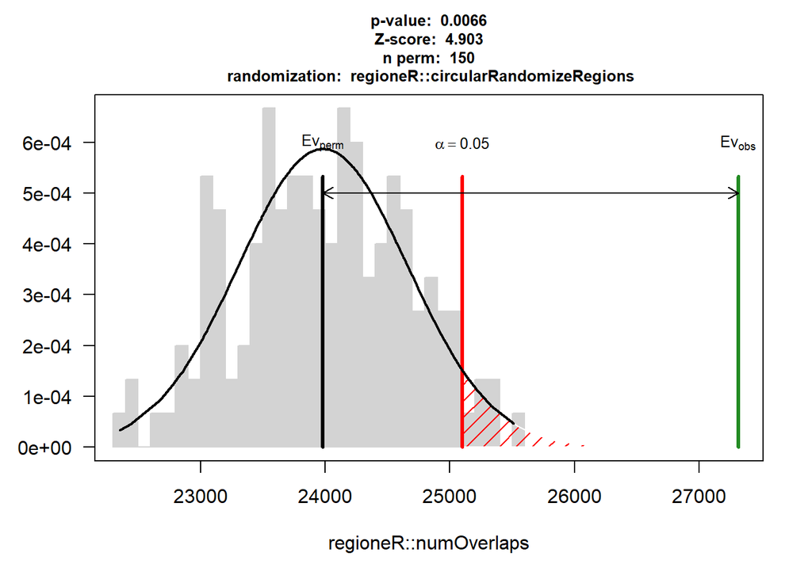

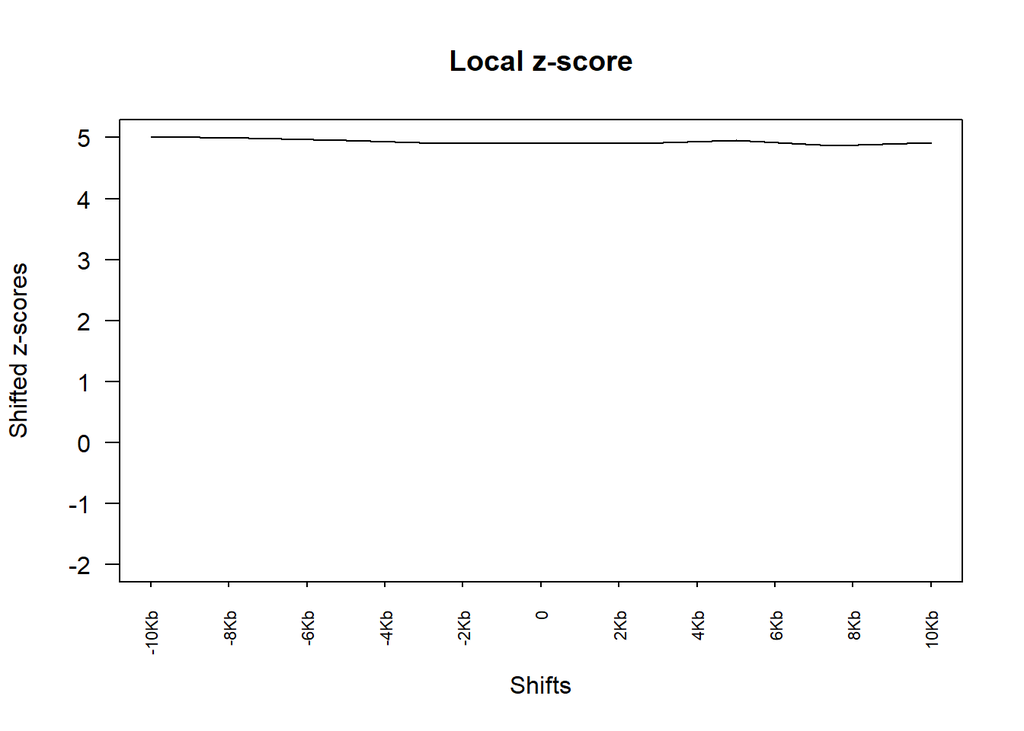

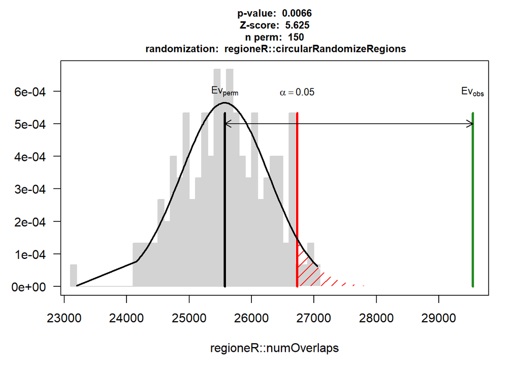

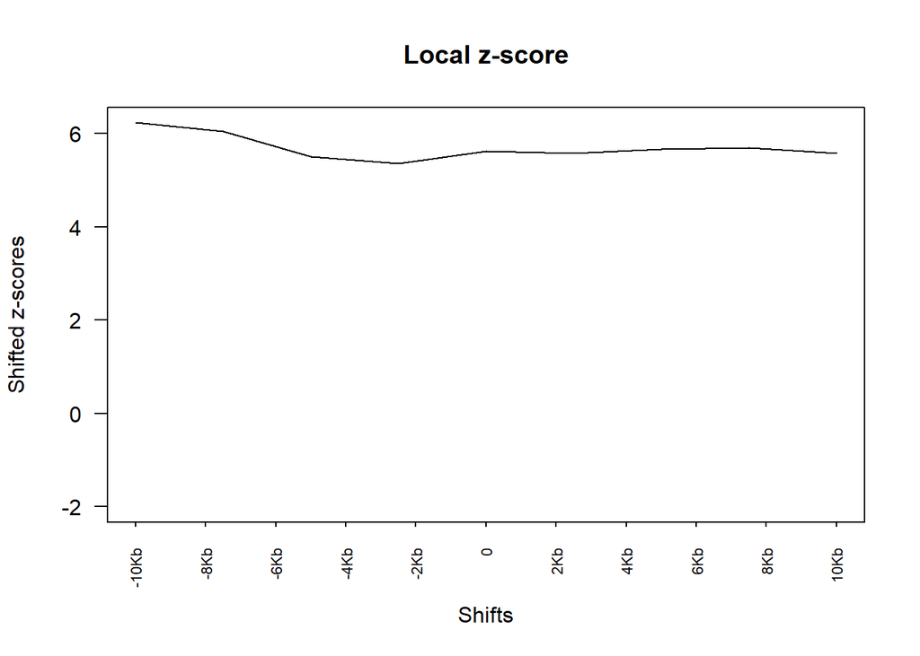

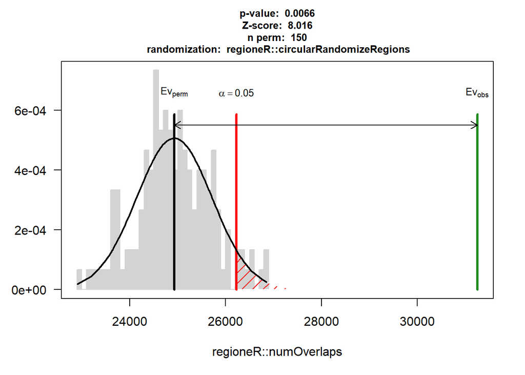

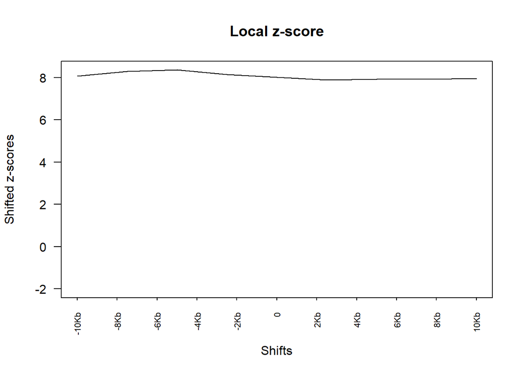

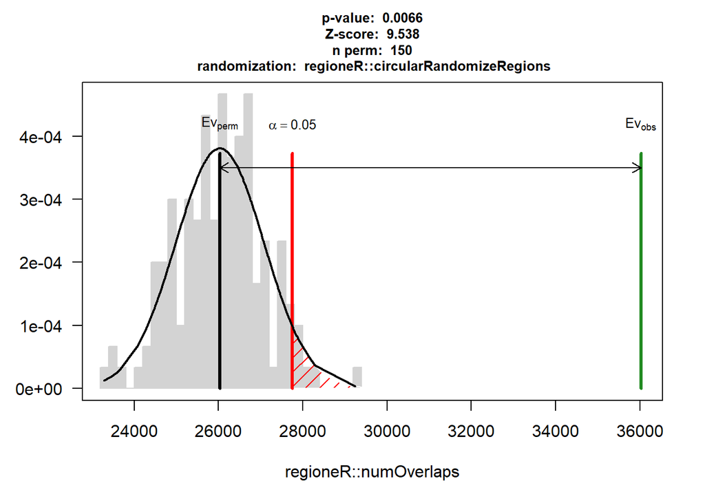

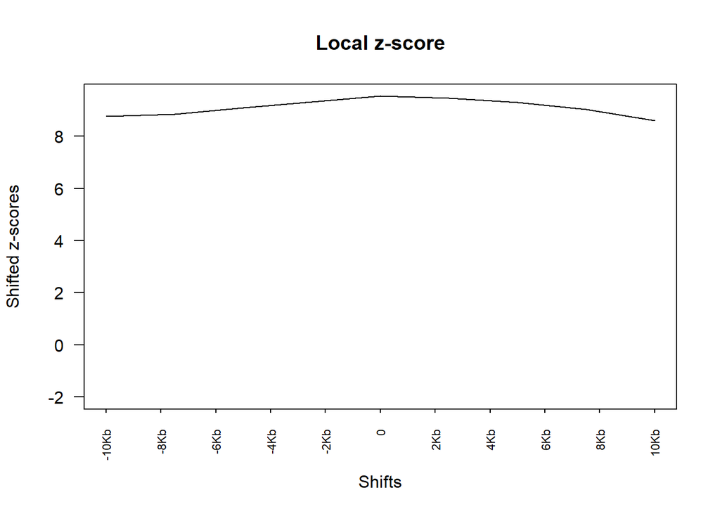

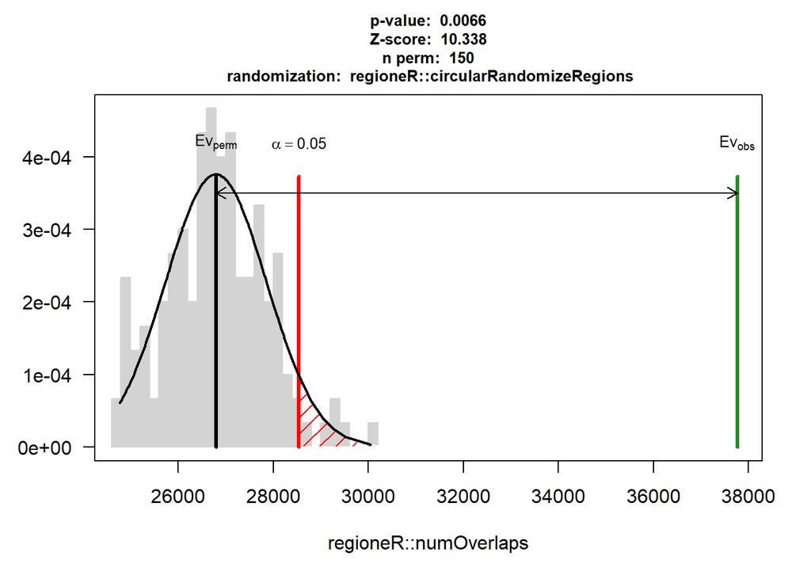

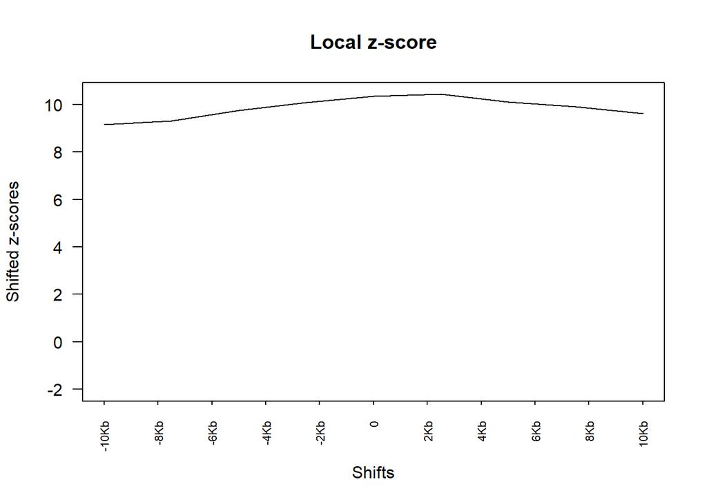

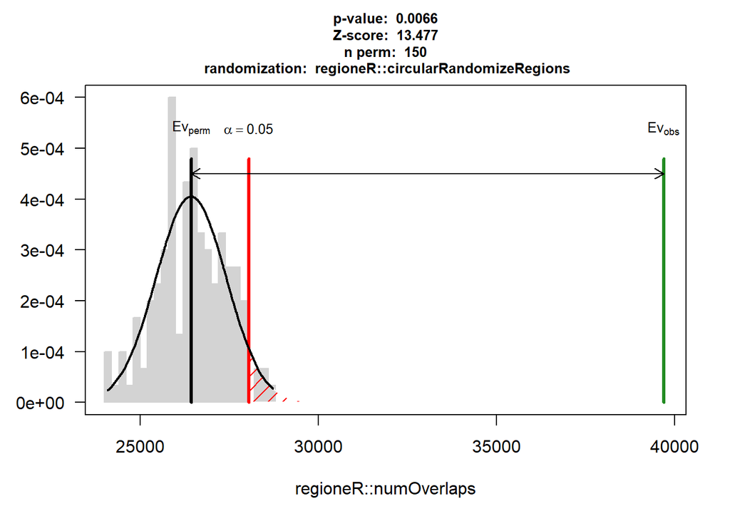

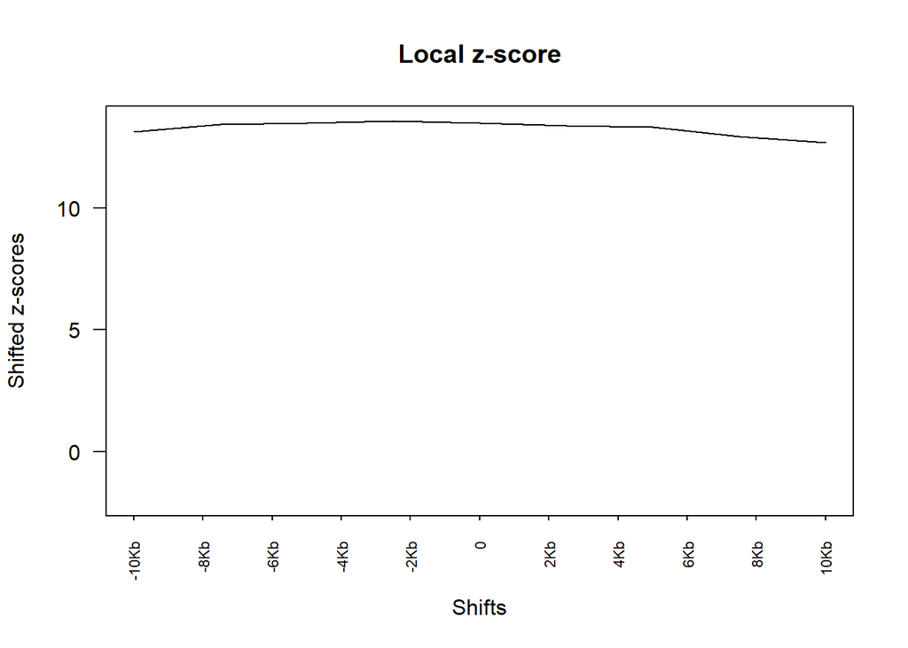

[10 more figures not shown]

In reviewing the results of the test for rl_cons it can no longer be assumed that there is no relationship between the whole set of windows and r-loop forming regions (given a significance threshold of 0.05). The same can also be said for each tenth in the ranked set.

The z score tends to increase with the percent score of each tenth.

Local z score across all tenths remains relatively flat, suggesting a regional relationship between rl_cons and the r-loop forming regions. This may be due to the windows being relatively large(10kb).

### Peak annotation and upset plots

Following this, I annotated the windows (by the same 10 increment groupings) and used upset plots to display the data. From our understanding of R-loops, I would expect that higher scoring windows would have a greater amount of peaks which span all of 3’ and 5’ untranslated regions (UTR), promoter, exons and introns. Lower scoring groups would have most peaks overlapping 1 or two of these regions.

[output not shown]

[output not shown]

[output not shown]

[output not shown]

[output not shown]

[output not shown]

[output not shown]

[output not shown]

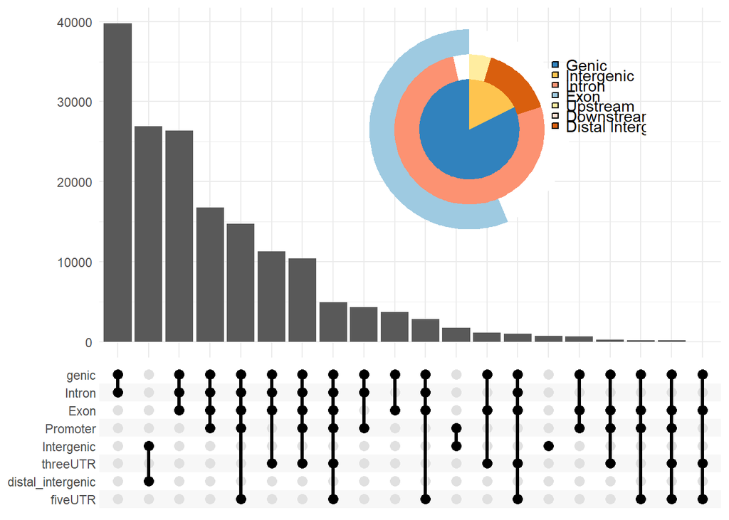

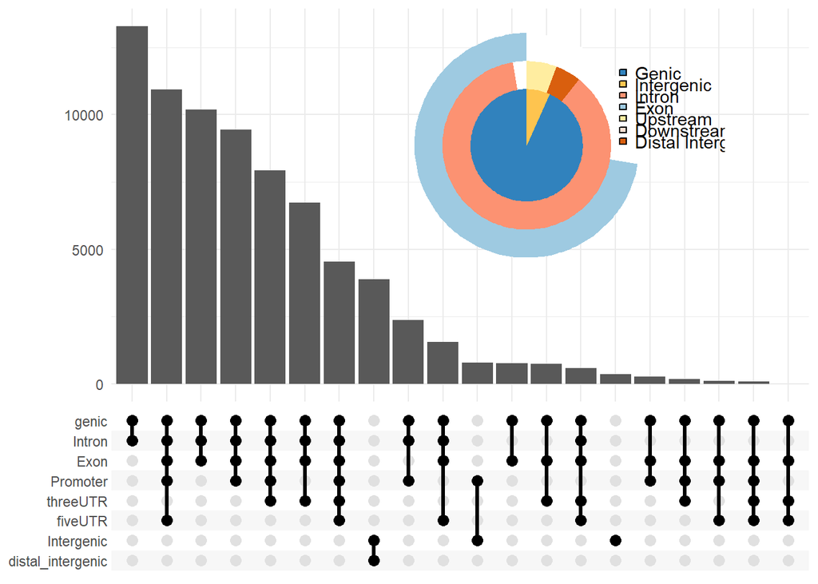

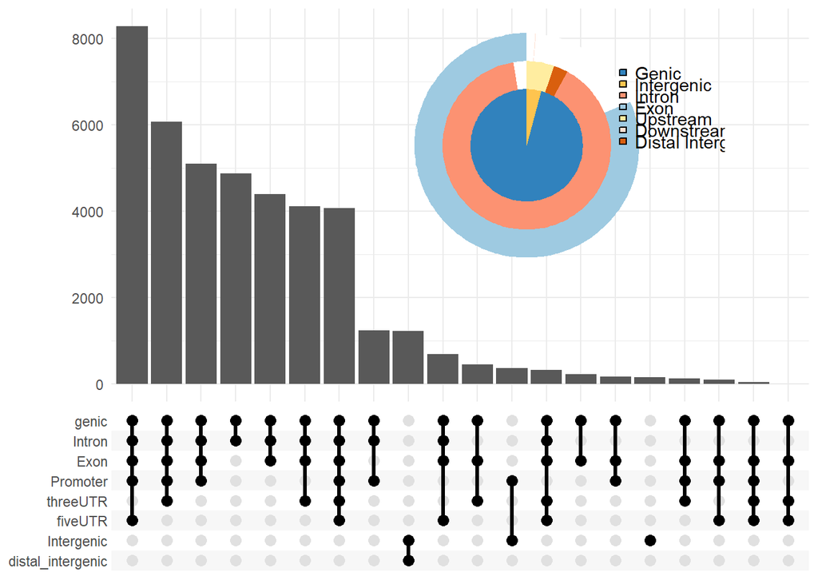

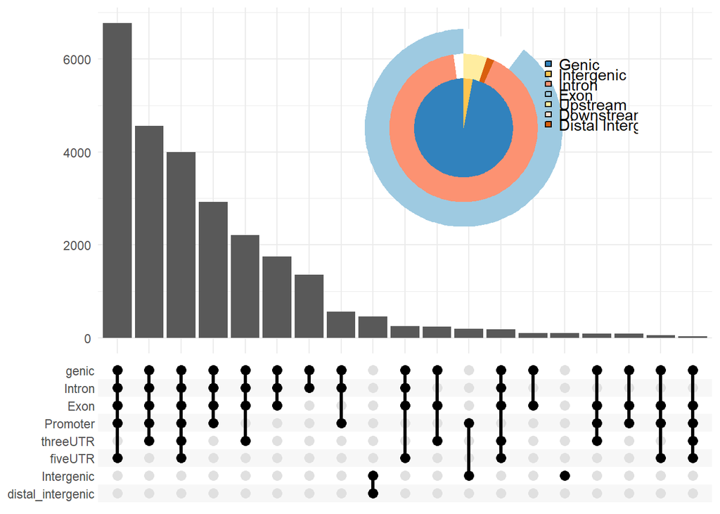

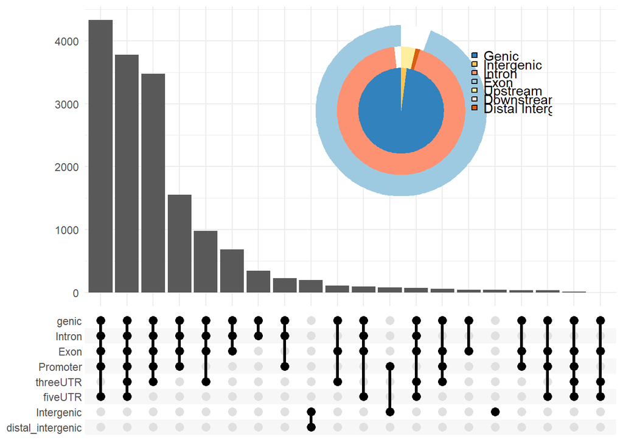

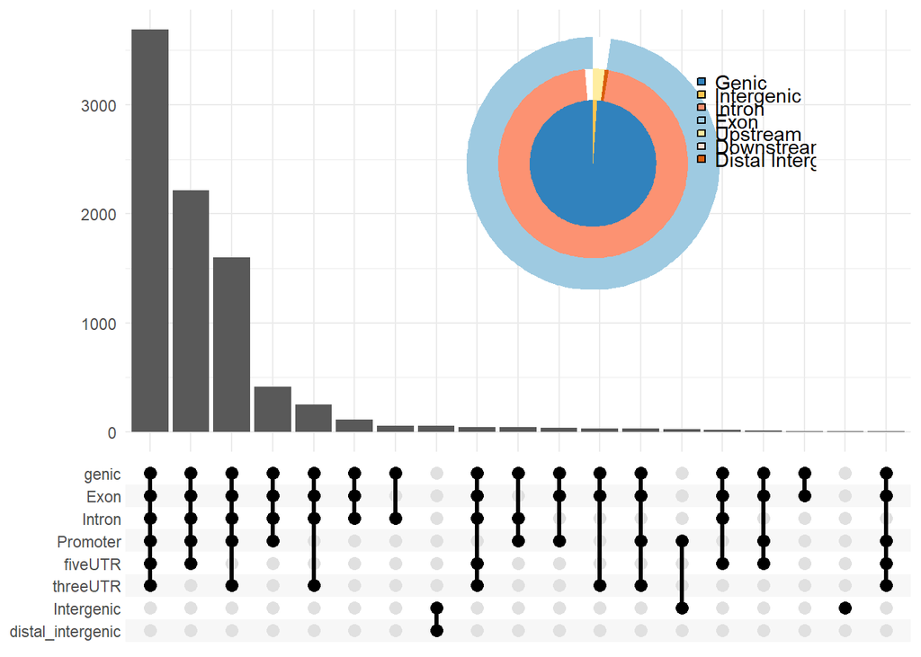

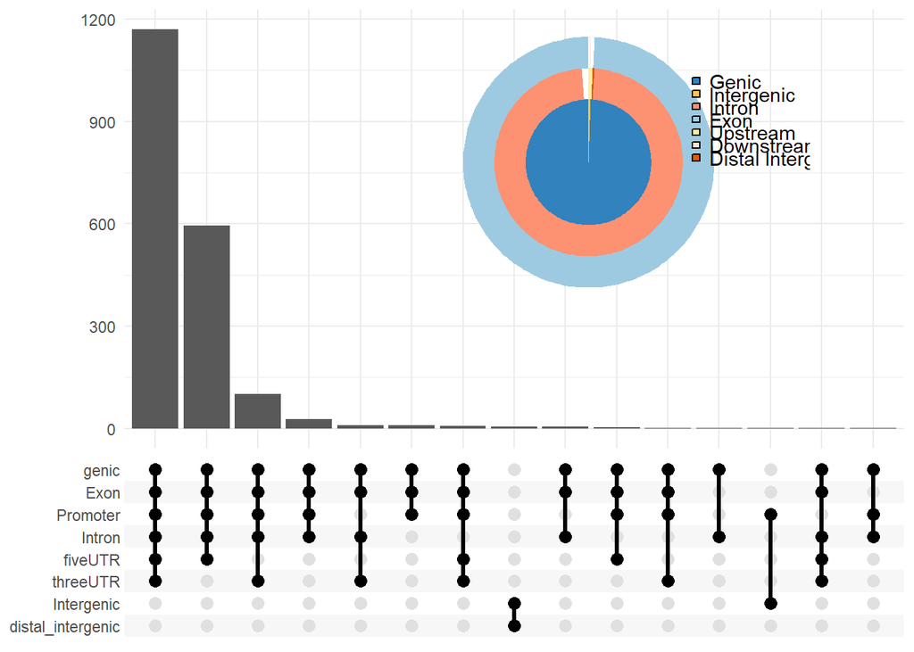

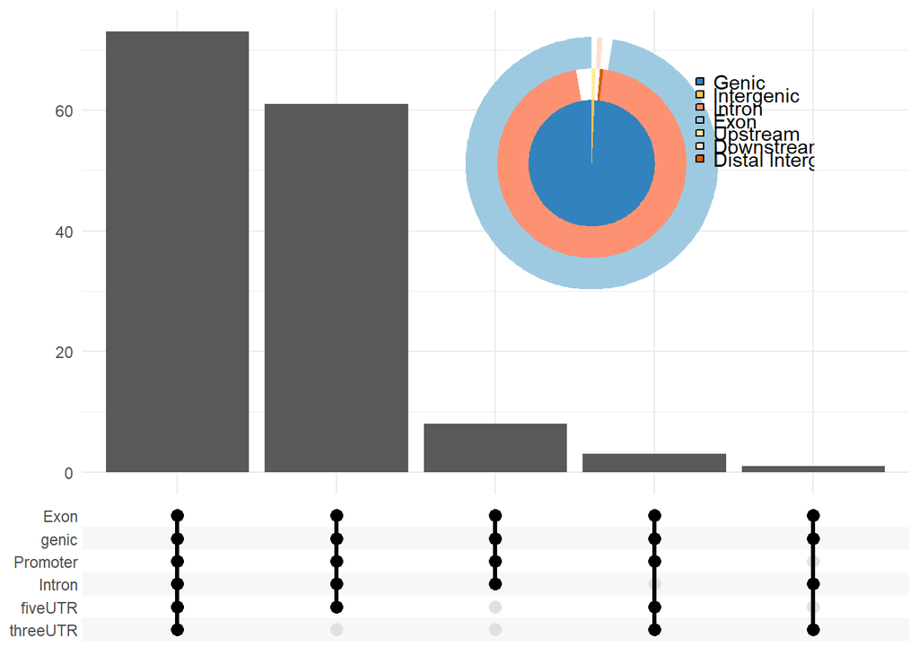

My hypothesis seems to hold true per the upset plots; higher scoring windows have more peaks which span the 5 relevant regions (introns, exons, promoters, 3’ and 5’ UTRs), whereas lower scoring peaks have fewer peaks spanning the 5 regions. This divide between higher and lower scoring windows is the same as the meta plots - after a 40% score, there is appears to be a divide in the trends which each group shows.

### Gene data tables

Below is the set of data tables storing the genetic information (start, end, width, name and description) for genes contained by each window. Again, windows were separated based on their percent scores.

```
## [1] "C:/Users/user/Documents/GitHub/RSeq-supplemental-analysis/misc/conservation_analysis"
```

```
##   1613 genes were dropped because they have exons located on both strands
##   of the same reference sequence or on more than one reference sequence,
##   so cannot be represented by a single genomic range.
##   Use 'single.strand.genes.only=FALSE' to get all the genes in a
##   GRangesList object, or use suppressMessages() to suppress this message.
```

```
## Annotate peaks by annoPeaks, see ?annoPeaks for details.
```

```
## maxgap will be ignored.
```

Gene data tables of the tenths using the same methods:

[output not shown]

```r
library(enrichR)
setEnrichrSite("Enrichr")
websiteLive<- TRUE

if(is.null(listEnrichrDbs()))
  print("DATABASES ARE NULL")
  websiteLive<-FALSE
```

### Enrichment analysis

Below is an enrichment analysis of some percent scoring groups. For each analysis I use the following work flow; a P.value threshold x (0.01<=x<=0.05) was used, then the set of terms were sorted in decending order [5][6].

For the 80-100% scoring group, I first began by comparing its gene set to the ChEA database.

-The highest ranking pathway is for the IKZF1 gene in male colorectal carcinoma cell lines [7]. IKZF1: expression is restricted to fetal and adult hemo-lymphopoietic system and functions as a regulator of lymphocyte differentiation [8]. All three of the genes enriched in this pathway serve some function to transfer phosphates. PRKCG code for a kinase, NPR1 is a guanylate cyclase and PTPN6 is a phosphatase. However, the kinase encoded by PRKCG is only exprssed in the brain and spinal cord [9].

Breakdown of top 5(human cell lines only):

80-100% Conservation: https://maayanlab.cloud/Enrichr/enrich?dataset=ae2bceb7fa582a59a487f4a25e3f2157 * IKZF1/HCT116 - Regulator of lymphoctye differentiation; colorectal cancer * KDM5A/BREAST - Gene regulation via histone demethylation[10]; * MYC/BL - Proto-oncogene, dimerizes and complexes with TF MAX to regulate transcription of target genes[11]; Burkitt lymphoma * DACH1/MDA-MB-231 - C ion and cell fate determination during development, highly conserved Ski domain between Drosophila and human[12]; late stage breast cancer model * LXR/THP-1 - cholestersol transport and now lipid and carbohydrate metabolism, cell diferentiation and apoptosis[13]; peripheral blood monocyte

```r
rl80100 <- rl_anno_2[which(rl_anno_2$pct_cons >80 & rl_anno_2$pct_cons <100 )]
rl80100_symbols <- unique(rl80100$symbol)
enriched80100 <- enrichr(rl80100_symbols, c("ChEA_2016","GO_Molecular_Function_2018", "GO_Cellular_Component_2018", "GO_Biological_Process_2018"))
```

```
## Uploading data to Enrichr... Done.
##   Querying ChEA_2016... Done.
##   Querying GO_Molecular_Function_2018... Done.
##   Querying GO_Cellular_Component_2018... Done.
##   Querying GO_Biological_Process_2018... Done.
## Parsing results... Done.
```

```r
e80100<-enriched80100[["ChEA_2016"]]
#datatable(e[e$P.value<=0.05,])
datatable(e80100[e80100$P.value>=0.01 & e80100$P.value<=0.05,],
          caption = "80-100% conservation",
          options = list(
          dom = 't',
          scrollX = TRUE,
          fixedColumns = list(leftColumns = 1),
          scrollCollapse = TRUE))
```

|  | Term | Overlap | P.value | Adjusted.P.value | Old.P.value | Old.Adjusted.P.value | Odds.Ratio | Combined.Score | Genes |
| --- | --- | --- | --- | --- | --- | --- | --- | --- | --- |
| 32 | DACH1 20351289 ChIP-Seq MDA-MB-231 Human | 16/1698 | 0.0142517779663293 | 0.236074297544388 | 0 | 0 | 1.96886823046157 | 8.36941000338861 | JMJD4;JUND;ZNF580;DAPK3;WDR74;ZNF3;SRP68;ILF2;HNRNPAB;THOC6;CLDN6;ATXN2L;C12ORF57;MYL6;SIX5;DVL2 |
| 33 | LXR 22292898 ChIP-Seq THP-1 Human | 18/2000 | 0.0145525251910924 | 0.236074297544388 | 0 | 0 | 1.89174665008331 | 8.00207082697871 | PPP1R14B;RPL3;PPAN-P2RY11;JUND;P2RY11;NPR1;GRIK5;MBD1;VEGFB;HNRNPU;ATP1A1;NEAT1;HNRNPAB;LRRC41;PLCB3;RBM15B;ANGPTL6;ZNF574 |
| 34 | MYB 26560356 Chip-Seq TH1 Human | 18/2000 | 0.0145525251910924 | 0.236074297544388 | 0 | 0 | 1.89174665008331 | 8.00207082697871 | FKBP2;JUN;PPP1R14B;JUND;WDR74;HNRNPU;NEAT1;SMG7;PPRC1;ATXN2L;C12ORF57;SYNCRIP;TMEM104;UBC;SNORD83B;MALAT1;PTPN6;IER5 |
| 35 | KLF4 26769127 Chip-Seq PDAC-Cell line Human | 18/2000 | 0.0145525251910924 | 0.236074297544388 | 0 | 0 | 1.89174665008331 | 8.00207082697871 | EIF5A;JUN;PPP1R14B;JUND;ZNF580;ZC3H4;DAPK3;WDR74;HNRNPU;C1ORF35;ATP1A1;ILF2;LRRC41;THOC6;MRPL55;C12ORF57;HNRNPF;IER5 |
| 36 | KLF6 26769127 Chip-Seq PDAC-Cell line Human | 18/2000 | 0.0145525251910924 | 0.236074297544388 | 0 | 0 | 1.89174665008331 | 8.00207082697871 | EIF5A;JUN;PPP1R14B;JUND;NPR1;VEGFB;HNRNPU;ATP1A1;GTPBP2;UQCRH;LRRC41;THOC6;MRPL55;C12ORF57;MYL6;CHTF8;UBC;IER5 |
| 37 | KDM5A 27292631 Chip-Seq BREAST Human | 11/1012 | 0.0160926702350334 | 0.254003227493501 | 0 | 0 | 2.23265981330497 | 9.21952617762321 | FKBP2;JUN;ZNF580;HNRNPF;UBC;WDR74;MAD2L1BP;C1ORF35;STX5;MALAT1;GABARAP |
| 38 | SPI1 23547873 ChIP-Seq NB4 Human | 25/3198 | 0.0213156510787714 | 0.327587900789539 | 0 | 0 | 1.66785017573115 | 6.41841065356753 | PHF23;CXXC1;ATP1A1;SMG7;GABARAP;SYNCRIP;GALR2;UBC;STX5;IER5;EIF5A;PPP1R14B;P2RY11;ZNF580;NEAT1;PPRC1;THOC6;MANF;ATXN2L;MYL6;ANGPTL6;HNRNPF;PTPN6;SNORD43;MIR5188 |
| 39 | TP53 22573176 ChIP-Seq HFKS Human | 13/1348 | 0.0224987878294234 | 0.328242895243343 | 0 | 0 | 1.98619582664526 | 7.53621060094007 | ANKRD17;EIF5A;JMJD4;SNAP47;JUN;ZC3H4;PHF23;WDR74;GPS2;SMG7;GABARAP;DVL2;STX5 |
| 40 | MYC 22102868 ChIP-Seq BL Human | 9/797 | 0.0230297778487801 | 0.328242895243343 | 0 | 0 | 2.29724819663372 | 8.66284762586807 | ATXN2L;SYNCRIP;FKBP2;ZC3H4;HNRNPF;MAD2L1BP;MALAT1;MYL6B;HNRNPAB |
| 41 | NANOG 18555785 ChIP-Seq MESCs Mouse | 7/542 | 0.0230444498372895 | 0.328242895243343 | 0 | 0 | 2.61156180749591 | 9.84645068234049 | SYNCRIP;COPS6;PLCB3;GRAMD1A;CXXC1;UQCRH;LRRC41 |

[output cut: 17 more lines]

70-80% Conservation: https://maayanlab.cloud/Enrichr/enrich?dataset=79c154d7f327e99466fcf36bb1b59a39 * ZNF652/ZR75-1 - Zinc finger[14]; mammary gland/breast/duct epithelial * PKCTHETA/BREAST - Activation of mature T cells [15]; * DMRT1/FETAL Ovary - Vertebrate sex determination [16]; * P68/HELA - RNA helicase, overexpresssion is implicated in several cancers[16]; cancerous-cervical epithelial * CREB1/LNCaP-abl - Induces transcription of genes in reponse to hormonal stimulation of cAMP pathway[18]; Prostate carcinoma

```r
rl7080 <- rl_anno_2[which(rl_anno_2$pct_cons >70 & rl_anno_2$pct_cons <80 )]
rl7080_symbols <- unique(rl7080$symbol)
enriched7080 <- enrichr(rl7080_symbols, c("ChEA_2016","GO_Molecular_Function_2018", "GO_Cellular_Component_2018", "GO_Biological_Process_2018"))
```

```
## Uploading data to Enrichr... Done.
##   Querying ChEA_2016... Done.
##   Querying GO_Molecular_Function_2018... Done.
##   Querying GO_Cellular_Component_2018... Done.
##   Querying GO_Biological_Process_2018... Done.
## Parsing results... Done.
```

```r
e7080<-enriched7080[["ChEA_2016"]]
#datatable(e[e$P.value<=0.05,])
datatable(e7080[e7080$P.value>=0.01 & e7080$P.value<=0.05,],
          options = list(
          dom = 't',
          scrollX = TRUE,
          fixedColumns = list(leftColumns = 1),
          scrollCollapse = TRUE))
```

|  | Term | Overlap | P.value | Adjusted.P.value | Old.P.value | Old.Adjusted.P.value | Odds.Ratio | Combined.Score | Genes |
| --- | --- | --- | --- | --- | --- | --- | --- | --- | --- |
| 84 | ZNF652 21678463 ChIP-ChIP ZR75-1 Human | 13/112 | 0.0103422300219821 | 0.0785516994526733 | 0 | 0 | 2.21299167618737 | 10.1167351846336 | TOE1;TNFRSF6B;MRPS34;NUP153;EEF2;PPOX;OCEL1;TNFRSF1A;SIX5;DNAJB4;ZNF768;NCDN;LDLR |
| 85 | P68 20966046 ChIP-Seq HELA Human | 136/2000 | 0.0112548873247606 | 0.0815979331045145 | 0 | 0 | 1.25227043390515 | 5.61887834955503 | ANKRD13D;MPI;MIR146B;APEH;CELSR3;PODNL1;RPS16;SIT1;FPGS;RCC1;PMPCA;LZTS2;JUNB;SRRM2;MAP1S;NEAT1;MIR324;ATXN2L;MIR1227;TBC1D24;NHP2;MALAT1;PHPT1;PRR14;HOMEZ;C11ORF95;RNASEH2C;INO80E;VCP;ISYNA1;RNASEH2A… |
| 86 | RUNX1 22412390 ChIP-Seq EML Mouse | 136/2000 | 0.0112548873247606 | 0.0815979331045145 | 0 | 0 | 1.25227043390515 | 5.61887834955503 | EIF4A1;HNRNPU;ALKBH7;COMTD1;PODNL1;FCGRT;RUSC1;SIT1;MYC;CCDC97;MAF1;JUNB;IER2;PLEKHJ1;SLC34A3;WSB2;TPM4;NEAT1;HNRNPUL1;HNRNPUL2;RFX5;MYADM;PRKD2;MALAT1;TLN1;KPNB1;ATF4;HOMEZ;FKBP2;NECAB3;MAZ;PSEN1;UBC… |
| 87 | CREB1 26743006 Chip-Seq LNCaP-abl Human | 136/2000 | 0.0112548873247606 | 0.0815979331045145 | 0 | 0 | 1.25227043390515 | 5.61887834955503 | MTCH1;ERRFI1;ANKRD13D;ZBTB25;HNRNPU;ENO1;CELSR3;CDC20;KRTCAP2;COMTD1;EFEMP2;ZFP36;IPO9;RAVER1;KAT5;FLAD1;CFL1;HCFC1R1;RPL36;RCC1;ZNF687;HMGN2;ATXN7L3;IER2;LAG3;NEAT1;ILF2;CACNB3;TBC1D24;MYADM;CD2BP2;M… |
| 88 | FOXA1 26769127 Chip-Seq PDAC-Cell line Human | 136/2000 | 0.0112548873247606 | 0.0815979331045145 | 0 | 0 | 1.25227043390515 | 5.61887834955503 | ERRFI1;CRTC2;AHCYL1;ANKRD13D;ZBTB25;POGK;NAB2;ATN1;RXFP4;ZDHHC8;ENO1;RCC1;ZNF687;LZTS2;IER5;JUNB;IER2;RAB2A;KHNYN;ATXN2L;MYL6;HNRNPUL1;CLDN9;ZC3H11A;RFX5;DDIT4;TAGLN2;SNRPE;MALAT1;DDX6;FKBP2;RBM8A;SHC… |
| 89 | SRY 25088423 ChIP-ChIP EMBRYONIC GONADS Mouse | 201/3083 | 0.0125464731127015 | 0.0894015254010353 | 0 | 0 | 1.20438882585438 | 5.27319448078543 | NUDT1;IFI35;ZDHHC8;IL4I1;RPL18A;RUSC1;RPL35;RPS11;SLC34A3;ENDOG;WSB2;MOGS;JMJD8;MYL6;CLDN9;CD2BP2;FAR1;TAGLN2;RPL27;PRKD2;NEIL1;DUS3L;AGAP2;AGAP3;MRPL12;SLC5A5;GJC2;DPH2;RRS1;KCNN1;RCE1;ZBTB7B;RHBDL1;… |
| 90 | PKCTHETA 26484144 Chip-Seq BREAST Human | 41/506 | 0.0126115004484219 | 0.0894015254010353 | 0 | 0 | 1.49454048595022 | 6.53584396813404 | ARF1;LEPROT;GPAA1;C1ORF35;TOB1;BBC3;MYC;KHSRP;ARHGDIA;ZNF747;UBC;AP2S1;KCNN1;ARIH1;ZNF687;HNRNPA1;IER5;TMED4;HEXIM1;KLF10;JUN;HSPA5;GADD45A;PRMT1;USP21;PHF12;IRF2BP2;NEAT1;NBPF1;LRRC41;MIR612;ATXN2L;E… |
| 91 | RARG 19884340 ChIP-ChIP MEFs Mouse | 33/390 | 0.0132412507170537 | 0.0928342632690142 | 0 | 0 | 1.56450002304395 | 6.76555247978209 | MIDN;NDUFB10;SHC1;TCIRG1;ALKBH7;SLC25A28;RRAS;IDH3B;JUNB;DEDD;PDLIM7;RPL19;CDKN2D;MBD6;TNFRSF12A;TNFSF13;HMGA1;RPL13A;RHOF;RHOC;RPL3L;VEGFA;CACNB1;SPSB2;NDUFS8;CTTN;HOOK2;DDIT3;FUBP1;FSCN1;STUB1;TAGLN… |
| 92 | ELF3 26769127 Chip-Seq PDAC-Cell line Human | 135/2000 | 0.0144644550220007 | 0.0992292720864136 | 0 | 0 | 1.24107065640405 | 5.25725102680493 | ERRFI1;SLC35B2;AHCYL1;ZBTB25;POGK;NAB2;RXFP4;HNRNPU;MIR146B;ENO1;CDC20;COMTD1;KAT5;FLAD1;RCC1;HMGN2;LZTS2;PHLDA3;KHNYN;FNDC3B;PTOV1;CSNK1E;LENEP;PYGO2;HNRNPUL2;ZC3H11A;RFX5;DDIT4;ERF;MYADM;FAR1;TAGLN2… |
| 93 | ZFP281 27345836 Chip-Seq ESCs Mouse | 135/2000 | 0.0144644550220007 | 0.0992292720864136 | 0 | 0 | 1.24107065640405 | 5.25725102680493 | SLC35B2;MIDN;TUSC2;NAB2;HNRNPU;BZW1;ACTG1;PNN;ZFP36;IPO9;PODNL1;TFG;MYC;CFL1;RPL36;RCC1;ATXN7L3;JUNB;IER2;PHLDA3;SNORD58B;MYLIP;WSB2;FNDC3B;CSNK1D;CSNK1E;NEAT1;MIF4GD;ATXN2L;CACNB1;CACNB3;CLDN9;DDIT4;… |

[output cut: 16 more lines]

60-70% Conservation: https://maayanlab.cloud/Enrichr/enrich?dataset=5ee5a9c14b529497c6dda82f4a953f18 * EGR1/THP-1 - products of targets are required for differentiation and mitogenisis[19]; peripheral blood monocyte * ZNF652/ZR75-1 - Zinc finger[14]; mammary gland/breast/duct epithelial * KDM6A/U937 and SAOS2 - catalyzes demethylation of histone H3[20]; Pleura/pleural effusion, lymphocyte, myeloid monocyte Histiocytic lymphoma + Bone epithelial Osteosarcoma * TP53/ IMR90 - Enducing cell cycle arrest, apoptosis, senescence and DNA repair in response to cellular stress[21];Lung fibroblast - normal * PKCTHETA/BREAST - - Activation of mature T cells [15];

```r
rl6070 <- rl_anno_2[which(rl_anno_2$pct_cons >60 & rl_anno_2$pct_cons <70 )]
rl6070_symbols <- unique(rl6070$symbol)
enriched6070 <- enrichr(rl6070_symbols, c("ChEA_2016","GO_Molecular_Function_2018", "GO_Cellular_Component_2018", "GO_Biological_Process_2018"))
```

```
## Uploading data to Enrichr... Done.
##   Querying ChEA_2016... Done.
##   Querying GO_Molecular_Function_2018... Done.
##   Querying GO_Cellular_Component_2018... Done.
##   Querying GO_Biological_Process_2018... Done.
## Parsing results... Done.
```

```r
e6070<-enriched6070[["ChEA_2016"]]
#datatable(e[e$P.value<=0.05,])
datatable(e6070[e6070$P.value>=0.01 & e6070$P.value<=0.05,],
          options = list(
          dom = 't',
          scrollX = TRUE,
          fixedColumns = list(leftColumns = 1),
          scrollCollapse = TRUE))
```

|  | Term | Overlap | P.value | Adjusted.P.value | Old.P.value | Old.Adjusted.P.value | Odds.Ratio | Combined.Score | Genes |
| --- | --- | --- | --- | --- | --- | --- | --- | --- | --- |
| 68 | KDM6A 18722178 ChIP-ChIP U937 AND SAOS2 Human | 98/479 | 0.0141009420943036 | 0.133336849509371 | 0 | 0 | 1.30214538400091 | 5.54911035246493 | ARID4A;TMEM91;CDC20;FCGRT;MAGOH;RCC1;MPV17;SNRPD3;SLC12A9;ABT1;SAP30BP;MEF2B;METTL1;CDC25C;BCS1L;ILF2;SLC5A6;TMEM79;MAPKAPK5;ASF1B;ATF4;COPA;TROAP;MYNN;HTRA2;MTMR4;ZBTB5;OSGEP;MRPL20;KLC4;EMG1;BLOC1S1… |
| 69 | FLI1 20887958 ChIP-Seq HPC-7 Mouse | 372/2030 | 0.0151703151488238 | 0.141369748415851 | 0 | 0 | 1.14422450919936 | 4.79248676742926 | EIF4A2;POP5;SLC35B2;RPL5;ARL6IP1;RPL31;GMFG;GORAB;SCARNA2;GPATCH3;RPL8;PHB2;RPL6;NUBP2;PNN;RPS14;RAVER1;PPP2R1A;TMEM88;FTH1;MAGOH;TBC1D10C;FAM53C;RPL36;RPL38;RPL37;RPS10;IER2;TBC1D10B;SLC34A3;TSPYL1;C… |
| 70 | SFPI1 20887958 ChIP-Seq HPC-7 Mouse | 430/2369 | 0.0166301647857724 | 0.152759942246452 | 0 | 0 | 1.13208574828673 | 4.63763124206446 | RPL5;RPL31;GMFG;ARPC5L;SLC4A2;ENO1;RPL8;PHB2;TSEN54;RPL6;LSM10;KRTCAP2;SAMD14;WDR90;ZXDC;RPL36;HOMER3;RPL38;PRKACA;IER2;ENDOG;TSPYL1;CSNK2A1;PIH1D1;MED8;FRS3;EML3;DDIT3;CLPP;ORAI3;RPL27;RPL28;DUS3L;PR… |
| 71 | SOX9 25088423 ChIP-ChIP EMBRYONIC GONADS Mouse | 349/1903 | 0.0176491465568087 | 0.159836637127155 | 0 | 0 | 1.14431536863332 | 4.61967878553554 | PNMT;CPNE7;AVIL;RRP1;NUDT1;SCX;ZDHHC8;ALKBH7;TXNDC17;KRTCAP2;TMEM88;AKT2;SOX15;LONP1;HOMER3;RPS11;EPHB4;TSPYL2;SMARCC1;MEF2B;PAQR4;ARRDC1;ACTN1;SLC35C2;FOXH1;WDR74;ZFYVE21;CSNK1D;MFSD11;MAPK8IP3;MIF4G… |
| 72 | TP53 22127205 ChIP-Seq IMR90 Human | 186/975 | 0.0193089578858721 | 0.172439721119663 | 0 | 0 | 1.19624482224456 | 4.72180099627043 | TRRAP;NAB2;ATN1;LOC344967;ENO2;GBA2;BEST4;PPP4R1;PODNL1;CAPNS1;MIR671;FLAD1;FDXR;SNORD99;SNORD12;ZNF205;SLC16A3;ATXN7L3;EPHB4;C2ORF81;C11ORF68;PHLDA3;SLC34A3;RPL23;TPM2;ATG9A;MIR27A;NEAT1;TMEM130;LENE… |
| 73 | RUNX2 24764292 ChIP-Seq MC3T3 Mouse | 365/2000 | 0.0199740485939932 | 0.175935797889556 | 0 | 0 | 1.13752665355607 | 4.45150741725011 | SLC35B2;AHCYL1;SCX;IFI30;NUDT3;LGALS2;KRTCAP2;LGALS1;CAPNS1;RPL18A;CLP1;FTH1;MYC;ZXDC;RPS10;IER5;SCN1B;IER2;SLC12A9;GAMT;SRRM2;LMAN1L;ACTN1;IFRD2;KRT8;ZFYVE21;MFSD11;GTPBP1;GTPBP3;TRIM17;RFX5;MXRA8;TA… |
| 74 | ELF3 26769127 Chip-Seq PDAC-Cell line Human | 364/2000 | 0.0231694540922805 | 0.201087272033253 | 0 | 0 | 1.13325762755072 | 4.26662487577261 | POP5;SLC35B2;ERRFI1;AHCYL1;GABPB2;FAM89B;PWWP2B;GORAB;RXFP4;HNRNPU;SCARNA2;ENO1;GABPB1;TSKU;CDC20;TIAL1;LSM10;COMTD1;LGALS1;KAT5;FLAD1;PPP2R1A;CLP1;ZC3H12A;MAGOH;SNORD99;RCC1;TBC1D10B;MIR194-2;SMARCC2… |
| 75 | ELF1 20517297 ChIP-Seq JURKAT Human | 193/1020 | 0.0234549695217636 | 0.201087272033253 | 0 | 0 | 1.18404449818622 | 4.4433316849152 | RPS15;KRTCAP3;RASSF1;ZC3H12A;RCC1;CCNL2;MAP1S;ARRDC2;ZNF12;GTPBP2;GTPBP1;MAPK8IP3;JMJD8;GTPBP4;EML3;GPR162;WDR82;PPP1R3E;ORAI3;CLDN7;CD2BP2;FLYWCH1;PRR14;NUMBL;TTYH2;CTBP1;XPC;MTMR4;MYL12A;RHOT2;BLOC1… |
| 76 | PKCTHETA 26484144 Chip-Seq BREAST Human | 101/506 | 0.0244812157427019 | 0.207123970033649 | 0 | 0 | 1.26179747253211 | 4.68107829341082 | SCARNA2;GABPB1;STK11;RASSF1;MYC;KHSRP;ARHGDIA;ZC3H12A;PRKACA;ZNF687;CCNL1;IER5;MAMSTR;WDR74;NEAT1;SRRM1;ATXN2L;HNRNPUL1;DDIT4;ERF;PGP;KDELR2;FLYWCH1;TRIB1;ANAPC2;KHDRBS1;DHX9;MTMR4;DEDD2;SEC14L1;UBC;K… |
| 77 | ZNF652 21678463 ChIP-ChIP ZR75-1 Human | 27/112 | 0.0257800583312255 | 0.214387221938288 | 0 | 0 | 1.60194112284841 | 5.86014735646005 | TNFRSF6B;SSNA1;MRPS34;TMEM95;HSPB1;PPOX;U2AF1L4;PPP3CA;TMEM147;SIX5;BGLAP;DNAJB4;HIVEP1;SLC25A42;NCDN;LDLR;TOE1;USP20;PPP1R16A;IRF2BP1;NUP153;EEF2;OCEL1;QKI;TNFRSF1A;SLC6A6;MYO1G |

[output cut: 6 more lines]

50-60% Conservation (unordered ranking): https://maayanlab.cloud/Enrichr/enrich?dataset=241b3fb3a27245fc21eea20ca0626605 * ELF3/PDAC-Cell line - Associated with Sarcoma, Synovial and Ampulla of Vater Cancer [22]; Pancreatic Ductal adenocarcinoma * KLF4/PDAC-Cell line - Mediates p53(tumor supressor) gene, thereby controlling G1-to-S cell cycle transition after Dna damage[23];Pancreatic Ductal adenocarcinoma * EGR1/THP-1 - products of targets are required for differentiation and mitogenisis[19]; peripheral blood monocyte * NR1H3/ AtherOSCLEROTIC-FOAM - Family members are regulators of macrophage function (controlling transcriptional programs involved in lipid homeostasis and inflammation) [24]; “Lipid filled” macrophages

```r
rl5060 <- rl_anno_2[which(rl_anno_2$pct_cons >50 & rl_anno_2$pct_cons <60 )]
rl5060_symbols <- unique(rl5060$symbol)
enriched5060 <- enrichr(rl5060_symbols, c("ChEA_2016","GO_Molecular_Function_2018", "GO_Cellular_Component_2018", "GO_Biological_Process_2018"))
```

```
## Uploading data to Enrichr... Done.
##   Querying ChEA_2016... Done.
##   Querying GO_Molecular_Function_2018... Done.
##   Querying GO_Cellular_Component_2018... Done.
##   Querying GO_Biological_Process_2018... Done.
## Parsing results... Done.
```

```r
e5060<-enriched5060[["ChEA_2016"]]
#datatable(e[e$P.value<=0.05,])
datatable(e5060[e5060$P.value>=0.01 & e5060$P.value<=0.05,],
          options = list(
          dom = 't',
          scrollX = TRUE,
          fixedColumns = list(leftColumns = 1),
          scrollCollapse = TRUE))
```

|  | Term | Overlap | P.value | Adjusted.P.value | Old.P.value | Old.Adjusted.P.value | Odds.Ratio | Combined.Score | Genes |
| --- | --- | --- | --- | --- | --- | --- | --- | --- | --- |
| 55 | ELF3 26769127 Chip-Seq PDAC-Cell line Human | 533/2000 | 0.0170155401065977 | 0.199545879431919 | 0 | 0 | 1.12233393323417 | 4.57197119229934 | IPO13;POP5;NCKAP1;GABPB2;PWWP2B;HNRNPU;DCAF8;ENO1;TSKU;GLS;ELK4;ZC3H12C;MIR554;COMTD1;PSMD7;MPRIP;CLP1;ZC3H12A;SNORD99;PKNOX1;HES7;PRKAB2;TSTD1;ZNF281;SYTL1;GTPBP1;HSPG2;WDR77;TMEM82;HOXB9;MIR196A2;RF… |
| 56 | MYC 18555785 ChIP-Seq MESCs Mouse | 327/1200 | 0.0186242783723376 | 0.214511777681389 | 0 | 0 | 1.15362495227186 | 4.59522188311759 | LTV1;RPL5;TCERG1;RPL30;TMEM41A;RPL3;RPL32;ARL6IP1;EIF4A3;RPL8;TSKU;CYB5D2;ACTB;RPL6;PDCD2L;NUBP2;GLS;RPL7;COMTD1;PSMD7;RPS19;RPL36AL;RPL36;RPL38;VPS35;DENR;CCNL1;EARS2;CDK5RAP3;RPS13;EIF2A;RPS12;PRKAB… |
| 57 | KLF4 26769127 Chip-Seq PDAC-Cell line Human | 532/2000 | 0.0194221348077356 | 0.219776788613851 | 0 | 0 | 1.11912858522892 | 4.41086837757111 | GABPB2;PWWP2B;SERPINE1;HNRNPU;DCAF8;ENO1;F11R;TSKU;ELK4;MIR554;COMTD1;ZMIZ1;ZC3H12A;STMN1;ZXDC;RPL36;AKT1;HES7;TSTD1;WSB2;WDR74;HPCAL1;SYTL1;HSPG2;GTPBP4;EML2;WDR77;TMEM82;RFX7;PARD3;ORAI3;PSME4;PRR11… |
| 58 | SFPI1 20887958 ChIP-Seq HPC-7 Mouse | 625/2369 | 0.0217989999929679 | 0.242419913714902 | 0 | 0 | 1.10762588071266 | 4.23765609010806 | RPL5;ANKLE1;GMFG;DCAF8;SLC4A2;ENO1;RPL8;TSEN54;RPL6;ELK4;KRTCAP2;SAMD14;RNF114;WDR90;ZXDC;RPL36;RPL38;PRKACA;CDK5RAP3;NUP214;HES7;VPS18;STARD3;PRKAB2;ENDOG;CSNK2A1;WSB2;SECISBP2;HPCAL1;MED8;RC3H1;FRS3… |
| 59 | EGR1 19374776 ChIP-ChIP THP-1 Human | 24/68 | 0.0325490817124396 | 0.355833181432603 | 0 | 0 | 1.66835119675682 | 5.71411306308019 | TCERG1;EGR1;JUN;NPM1;MAP2K2;GADD45B;HDAC1;PRKDC;BRCA1;AFF1;MLLT11;HAX1;RAD51;DMTF1;CDK4;AKT1;MAPK1;MAP3K8;IKBKG;CALR;GABPA;MYD88;YWHAH;ATF4 |
| 60 | NR1H3 23393188 ChIP-Seq ATHEROSCLEROTIC-FOAM Human | 167/599 | 0.0372728594720168 | 0.400683239324181 | 0 | 0 | 1.18639648194755 | 3.9026391798403 | ANKRD39;MIDN;ZFAND3;UBP1;IRS2;IFI30;ACTB;POFUT2;RUSC1;PIM1;LONP1;FBXO6;UBAP2L;PHLDA1;STK32C;SLC12A9;PIAS4;MYLIP;TLE3;WSB1;C17ORF49;USP3;RFX2;TOMM34;CNPY3;KCTD3;GTPBP2;THOC5;LEMD2;SYTL3;WDR77;CACNB3;WD… |
| 61 | HCFC1 20581084 ChIP-Seq MESCs Mouse | 89/306 | 0.0430370433153887 | 0.455063818662717 | 0 | 0 | 1.25665140711804 | 3.95304086898823 | GSK3A;TXNL4B;DDX49;MRPS14;ARHGAP1;BRCA1;TNFAIP1;PRPF19;MRPL34;RPL10A;NUBP2;TIAL1;CHCHD4;TMEM101;ING3;RPS19;TMEM43;DENR;ACP2;HMG20A;CIC;MAF1;GTSE1;RPP38;AP2M1;YWHAG;POLG;PRMT5;CNTD1;DFFA;RNF44;SMARCC2;… |

40-50% Conservation: https://maayanlab.cloud/Enrichr/enrich?dataset=f3ef676d09ac7fd0ee717c2cd6c7f577 * Percent score 40-50%; very low combined score. Therefore lower Z score; pathways are not significantly enriched compared to the mean rank at this conservation level(?). * General trend before this group was a decrease in number of terms which are enriched. * E2F1/MCF-7 - plays a role in cell cycle progression and controls tumor suppresor protiens [25];Breast epithelial Adenocarcinoma * EOMES/HESCs - Development of the mesoderm and and central nervous system in vertebrates [26]. Recently, the tf also regulates the differentiations of certain NKT cells in the thymus[27]; * ELK1/HELA - Implicated to target several genes which have roles in certain neurological phenotypes[29];cancerous-cervical epithelial * MYC/BL - Proto-oncogene, dimerizes and complexes with TF MAX to regulate transcription of target genes[11]; Burkitt lymphoma * SA1/ ERYTHROID - Encodes a compoment of cohesin(under the alias STAG1) [28];

```r
rl4050 <- rl_anno_2[which(rl_anno_2$pct_cons >40 & rl_anno_2$pct_cons <50 )]
rl4050_symbols <- unique(rl4050$symbol)
enriched4050 <- enrichr(rl4050_symbols, c("ChEA_2016"))
```

```
## Uploading data to Enrichr... Done.
##   Querying ChEA_2016... Done.
## Parsing results... Done.
```

```r
e4050<-enriched4050[["ChEA_2016"]]
#datatable(e[e$P.value<=0.05,])
datatable(e4050[e7080$P.value>=0.01 & e7080$P.value<=0.05,],
          options = list(
          dom = 't',
          scrollX = TRUE,
          fixedColumns = list(leftColumns = 1),
          scrollCollapse = TRUE))
```

|  | Term | Overlap | P.value | Adjusted.P.value | Old.P.value | Old.Adjusted.P.value | Odds.Ratio | Combined.Score | Genes |
| --- | --- | --- | --- | --- | --- | --- | --- | --- | --- |
| 84 | E2F1 21310950 ChIP-Seq MCF-7 Human | 347/1145 | 0.744945039968254 | 0.999994258751234 | 0 | 0 | 0.959288631372684 | 0.282457582953184 | RB1;VPS29;IPO11;TMEM41B;TMEM97;GCC1;NUBP1;NUBP2;EPS8;PNN;ALKBH5;ZFYVE27;ALCAM;RAVER1;RUSC2;PSMD5;PPAT;WDR90;GPBP1;BSG;SAP130;CHEK1;AP1S1;FBXO5;CDK5RAP3;SOX4;TMPO;ARL6IP6;ALG8;MBNL2;COG4;RFX1;C9ORF64;A… |
| 85 | EOMES 21245162 ChIP-Seq HESCs Human | 281/932 | 0.758782225018151 | 0.999994258751234 | 0 | 0 | 0.952345048956515 | 0.262885771408353 | TDRKH;APP;TES;ZMYND8;ZDHHC5;CISD1;TESK2;JMJD1C;TMEM97;THUMPD1;ADARB1;GABPB1;SMC4;CYB5D2;RAPGEFL1;IKZF5;RPS14;RPS6KA3;ALKBH5;ZNF609;TBK1;AP1S1;PRSS8;PIP4K2C;PKNOX1;GLUL;PDK2;STARD3;PDHX;MBNL2;GLCE;FNDC… |
| 86 | ELK1 19687146 ChIP-ChIP HELA Human | 276/916 | 0.761000884297726 | 0.999994258751234 | 0 | 0 | 0.951474294354839 | 0.259867381538769 | EIF4A2;POP5;CPNE8;CHIC2;RPL30;IPO11;TP53RK;CCNH;PANK1;GHITM;ALKBH6;PEX26;GLS;RPS14;PSMD6;HOXA9;TBK1;CSPP1;CDC27;RCC1;SEC63;ABT1;GABARAPL2;PDHX;SMARCC1;SLC11A2;DNTTIP2;WDR75;PRKAB1;NIF3L1;GRWD1;RFX5;HM… |
| 87 | MYC 22102868 ChIP-Seq BL Human | 239/797 | 0.774618683316729 | 0.999994258751234 | 0 | 0 | 0.945025856842682 | 0.241344854098871 | TRAF3IP2;DCAF5;ICAM1;SPIB;SCAMP4;RPS14;CAPNS1;DLEU1;DLEU2;CHAC1;TBC1D22A;CHID1;SMARCC1;NUP210;ZNF282;LMAN1L;ARRDC2;EBF1;SOX12;EML2;PISD;RFX7;NINJ1;ORAI1;TRIB1;NEIL1;SEH1L;TMEM161A;CDCA4;EPB41;MYCBP2;M… |
| 88 | SA1 27219007 Chip-Seq ERYTHROID Human | 608/2000 | 0.781637570878517 | 0.999994258751234 | 0 | 0 | 0.962163046590584 | 0.237042442859224 | IPO13;MAPKBP1;POP7;TMEM200B;AVIL;TESK2;NOC2L;ENO2;LSM10;NDST1;LSM12;AS3MT;CAPNS1;STMN1;FDXR;PRSS8;DLEU2;GTSE1;CHID1;CLEC11A;RPL22;SNORA2A;HSPG2;RNF126;PRR19;CLNS1A;RFX5;TARS2;HOXB8;HOXB6;PIF1;CTBP2;C1… |
| 89 | THRA 23701648 ChIP-Seq CEREBELLUM Mouse | 51/179 | 0.801455339909079 | 0.999994258751234 | 0 | 0 | 0.880084385624089 | 0.19478558236284 | OTUD5;CCDC120;ECE1;ACTB;HERPUD1;AIFM3;ARL6IP5;EP300;SLC26A11;ARID2;S100A1;DAPK2;SIRT5;TMC8;CDC25B;FCHSD1;QTRT1;ARL4D;MAG;ADORA2B;CTDSP2;MMRN2;BMP2K;TOP1;SYNC;OBSL1;MTRF1L;ITIH4;THBS3;ANKMY2;MTA1;SLC17… |
| 90 | RARG 19884340 ChIP-ChIP MEFs Mouse | 114/390 | 0.809468473051712 | 0.999994258751234 | 0 | 0 | 0.911749228427984 | 0.192723229517635 | OTUD5;JRK;OXNAD1;TRAF3IP2;AQP5;LOXL2;HOXA10;LIPE;TUBB6;CAPNS1;FTH1;KIF5B;BSG;PRSS8;GABARAPL1;MED9;PCOLCE;RFX1;ATP11A;TPST2;CLPP;DMWD;SHPK;S100A4;S100A3;NUPR1;PSMD12;CTBP2;ABCB8;AEBP1;PTTG1IP;LTBP3;BCL… |
| 91 | ZNF652 21678463 ChIP-ChIP ZR75-1 Human | 31/112 | 0.814085159202951 | 0.999994258751234 | 0 | 0 | 0.845532585460508 | 0.173917851388274 | WDR27;FOXC2;PUS10;TRAF3IP2;TMEM95;HSPB1;CRIP2;EFNA4;DUSP10;HYAL1;HIVEP1;LDLR;USP47;TIA1;USP20;PNPLA7;RPS5;PPP2R5B;CRLS1;C6ORF120;C9ORF64;QKI;GALNS;SLC6A6;STAG1;SNX14;PTRH1;IGFALS;ALDH18A1;ERGIC1;MYO1G |
| 92 | NANOG 21062744 ChIP-ChIP HESCs Human | 250/840 | 0.820848594222093 | 0.999994258751234 | 0 | 0 | 0.934358183395614 | 0.184457818393432 | RB1;CHIC2;CCNK;RPL30;PLEKHB2;GMFG;TESK2;ICAM4;ICAM5;RPL9;ELK1;LSM12;PSMD7;CDC27;FBXO7;SEC63;CDK5RAP2;TBC1D10B;CHID1;SECISBP2;NSMCE2;CLEC11A;FRS2;SOX12;EML4;MYL4;CLDN5;SFRP5;PRR11;OBSL1;PRR13;PIF1;TEX2… |
| 93 | UTX 26944678 Chip-Seq JUKART Human | 605/2000 | 0.824102193739761 | 0.999994258751234 | 0 | 0 | 0.954615484151434 | 0.184680613429567 | ATF1;RPL5;TESK2;DCAF8;STMN3;ADARB1;PPP4R2;STMN1;DLEU2;HES7;PRKAB2;MEF2B;NUP210;ARMC7;PRKAB1;BCR;MYL4;RFX7;CLDN9;ZC3H11A;CLNS1A;CLPP;HMBS;RFX5;ORAI1;TARS2;PRKD2;PRR12;SEH1L;SAR1A;TPRG1L;NAIF1;MYNN;AGAP… |

[output cut: 16 more lines]

30-40% Conservation: https://maayanlab.cloud/Enrichr/enrich?dataset=3ea142080e4a4d7c3de3d0d4f5d9e3b9 - E2F7/HELA - Cell cycle progression[31]; cancerous-cervical epithelial - FOXM1/OE33 and U2OS - Implicated in DNA drepair, senscence, and tumor proliferation[30]; Human esophagus and Epithelial bone Osteosarcoma (respectively)

```r
rl3040 <- rl_anno_2[which(rl_anno_2$pct_cons >30 & rl_anno_2$pct_cons <40 )]
rl3040_symbols <- unique(rl3040$symbol)
enriched3040 <- enrichr(rl3040_symbols, c("ChEA_2016","GO_Molecular_Function_2018", "GO_Cellular_Component_2018", "GO_Biological_Process_2018"))
```

```
## Uploading data to Enrichr... Done.
##   Querying ChEA_2016... Done.
##   Querying GO_Molecular_Function_2018... Done.
##   Querying GO_Cellular_Component_2018... Done.
##   Querying GO_Biological_Process_2018... Done.
## Parsing results... Done.
```

```r
e3040<-enriched3040[["ChEA_2016"]]
#datatable(e[e$P.value<=0.05,])
datatable(e3040[e3040$P.value>=0.01 & e3040$P.value<=0.05,],
          options = list(
          dom = 't',
          scrollX = TRUE,
          fixedColumns = list(leftColumns = 1),
          scrollCollapse = TRUE))
```

|  | Term | Overlap | P.value | Adjusted.P.value | Old.P.value | Old.Adjusted.P.value | Odds.Ratio | Combined.Score | Genes |
| --- | --- | --- | --- | --- | --- | --- | --- | --- | --- |
| 3 | FOXM1 25889361 ChIP-Seq OE33 AND U2OS Human | 371/932 | 0.0280010175460495 | 0.999996454919716 | 0 | 0 | 1.1432075562181 | 4.08755511207022 | IPO11;PGAP2;PANK1;LRR1;TESK2;NUDT2;GHITM;F11R;MKI67;TMEM91;SMC4;RPL9;DCAF7;EPS8;ALKBH2;FRAT1;SNRPD3;ATXN7L1;SEPHS1;TBC1D22A;SAMD10;PDK2;PRKCI;ZNF281;CMC2;IFT80;SOX12;PASK;KNSTRN;BTD;THAP8;SNHG10;TXNIP… |
| 4 | E2F7 22180533 ChIP-Seq HELA Human | 23/46 | 0.0457515114094558 | 0.999996454919716 | 0 | 0 | 1.72001090512541 | 5.30542601382994 | FANCI;SLBP;CASP8AP2;DUT;PCNA;GOLT1B;RIF1;ATAD2;CDCA7;RECQL;BRCA1;CDC6;CDC25A;NBR2;RBL1;MSH2;MCM3;RAD54L;CENPM;MCM5;INTS7;MCM6;DTL |

20-30% Conservation: https://maayanlab.cloud/Enrichr/enrich?dataset=0ccdc80016e7b3d65a0f3b3af2cfbea7

```r
rl2030 <- rl_anno_2[which(rl_anno_2$pct_cons >20 & rl_anno_2$pct_cons <30 )]
rl2030_symbols <- unique(rl2030$symbol)
enriched2030 <- enrichr(rl2030_symbols, c("ChEA_2016","GO_Molecular_Function_2018", "GO_Cellular_Component_2018", "GO_Biological_Process_2018"))
```

```
## Uploading data to Enrichr... Done.
##   Querying ChEA_2016... Done.
##   Querying GO_Molecular_Function_2018... Done.
##   Querying GO_Cellular_Component_2018... Done.
##   Querying GO_Biological_Process_2018... Done.
## Parsing results... Done.
```

```r
e2030<-enriched2030[["ChEA_2016"]]
#datatable(e[e$P.value<=0.05,])
datatable(e2030[e2030$P.value>=0.01 & e2030$P.value<=0.05,])
```

|  | Term | Overlap | P.value | Adjusted.P.value | Old.P.value | Old.Adjusted.P.value | Odds.Ratio | Combined.Score | Genes |
| --- | --- | --- | --- | --- | --- | --- | --- | --- | --- |

```r
rl1020 <- rl_anno_2[which(rl_anno_2$pct_cons >10 & rl_anno_2$pct_cons <20 )]
rl1020_symbols <- unique(rl1020$symbol)
enriched1020 <- enrichr(rl1020_symbols, c("ChEA_2016","GO_Molecular_Function_2018", "GO_Cellular_Component_2018", "GO_Biological_Process_2018"))
```

```
## Uploading data to Enrichr... Done.
##   Querying ChEA_2016... Done.
##   Querying GO_Molecular_Function_2018... Done.
##   Querying GO_Cellular_Component_2018... Done.
##   Querying GO_Biological_Process_2018... Done.
## Parsing results... Done.
```

```r
e1020<-enriched1020[["ChEA_2016"]]
#datatable(e[e$P.value<=0.05,])
datatable(e1020[e1020$P.value>=0.01 & e1020$P.value<=0.05,])
```

|  | Term | Overlap | P.value | Adjusted.P.value | Old.P.value | Old.Adjusted.P.value | Odds.Ratio | Combined.Score | Genes |
| --- | --- | --- | --- | --- | --- | --- | --- | --- | --- |

```r
rl10 <- rl_anno_2[which(rl_anno_2$pct_cons <10 )]
rl10_symbols <- unique(rl10$symbol)
enriched10 <- enrichr(rl10_symbols, c("ChEA_2016","GO_Molecular_Function_2018", "GO_Cellular_Component_2018", "GO_Biological_Process_2018"))
```

```
## No genes have been given
```

```r
e10<-enriched10[["ChEA_2016"]]
#datatable(e[e$P.value<=0.05,])
datatable(e10[e10$P.value>=0.01 & e10$P.value<=0.05,])
```

[interactive table not shown]

```r
dataLst <- list(
  "10-13% Conservation" = c(rlAnnoRankedList[[1]]$symbol),
  "13-17% Conservation" = c(rlAnnoRankedList[[2]]$symbol),
  "17-22% Conservation" = c(rlAnnoRankedList[[3]]$symbol),
  "22-27% Conservation" = c(rlAnnoRankedList[[4]]$symbol),
  "27-33% Conservation" = c(rlAnnoRankedList[[5]]$symbol),
  "33-39% Conservation" = c(rlAnnoRankedList[[6]]$symbol),
  "39-46% Conservation" = c(rlAnnoRankedList[[7]]$symbol),
  "46-54% Conservation" = c(rlAnnoRankedList[[8]]$symbol),
  "54-63% Conservation" = c(rlAnnoRankedList[[9]]$symbol),
  "63-87% Conservation " = c(rlAnnoRankedList[[10]]$symbol)

)

enrichLinks <- lapply(names(dataLst), function(group) {
  genes<- dataLst[[group]]
  response <- httr::POST(url = 'https://maayanlab.cloud/Enrichr/addList', body = list(
    'list' = paste0(genes, collapse = "\n"),
    'description' = group
  ))
  jsonlite::fromJSON(httr::content(response, as = "text"))
})
names(enrichLinks) <- names(dataLst)
for(i in enrichLinks){print(paste0("https://maayanlab.cloud/Enrichr/enrich?dataset=",i$shortId))}
```

```
## [1] "https://maayanlab.cloud/Enrichr/enrich?dataset=08a011d0f5bf7d9778ddb2894b958f92"
## [1] "https://maayanlab.cloud/Enrichr/enrich?dataset=e7d0cedeaf9b9d8e1acf40a0550867bc"
## [1] "https://maayanlab.cloud/Enrichr/enrich?dataset=11b191d32252b8aab1299f916124e786"
## [1] "https://maayanlab.cloud/Enrichr/enrich?dataset=57db4aee2b349f2574b0179867a6e303"
## [1] "https://maayanlab.cloud/Enrichr/enrich?dataset=83630a89d8423996046b031390e5daa3"
## [1] "https://maayanlab.cloud/Enrichr/enrich?dataset=3e3c3700d31e8ba3039d64f9aa6bc176"
## [1] "https://maayanlab.cloud/Enrichr/enrich?dataset=4758389c7df9d586a25bf81b1b2810bf"
## [1] "https://maayanlab.cloud/Enrichr/enrich?dataset=f95ea5c937f4e419948c0bf49d3d6a83"
## [1] "https://maayanlab.cloud/Enrichr/enrich?dataset=9dd5bc41ef420b9694a568d0547351f9"
## [1] "https://maayanlab.cloud/Enrichr/enrich?dataset=81730211b9b2d3fd0706b8c4b8e49b63"
```

General observations: Many of the higher ranking pathways within each conservation group play a role in cell differentation or cell cycle progression. As well, many of these pathways are implicated in the regulation of tumor supressing or proliferating pathways. A trend within the overall data set is that there is a decrease in the number of enriched pathways as percent score decreases - with the exception of the 40-50% group and the groups with less than 30% conservation. For the former, there are no enriched pathways. Perhaps there is a correlation between the enrichment of transcription factors and their closeness to a TSS (see Metaplot analysis for <30% conseration groups).

### Discussion/Conclusion

Using the percent score as a metric for what is a highly conserved R loop prooves to be an effective tool which aligns with what we currently know about Rloops. Windows with higher percent scores are more likely to share characteristics which are expected of Rloop regions. High percent scoring windows are more likely to be closer to the TSS of gene and still have a notable presence surrounding it. Conversely, lower percent scoring windows have little presence near the TSS. Upset plots show a similar distinction between lower percent scoring windows and high percent scoring windows; as the percent score increases there is a greater presence of peaks which overlap whole genes. This is expected as the region which Rloops span may overlap large portions of a gene on a template strand. Finally, we see that pathwys which are implicated in Rloop formation - such as the M phase and transcription and translational roles - are more present in windows with higher percent scores.

From here there are several avenues on which to continue this sort of work. Some next steps might be to analyze how Rloops are conservered among different species. Another might be to analyze the correlation between conserved genes and Rloops which may form from them - this idea comes the the presence of the Rho GTPase pathway in many percent score groups. More over, one could explore the presence of neuronal pathways in less conserved Rloops, as Rloops are implicated in many neurological diseases [1]. Finally, one could look at the difference in CG content between lesser and highly conserved Rloops. Rloops are found to form over unmethylated CpG islands [4] (which are characteristic of euchromatic regions) and so perhaps this may be another characteristic of highly conserved Rloops.

It is important to note that any trend extracted from analyzing the 70-100% percent scoring groups may have a bias due to their sample size (there are less than 500 windows with a percent score greater than 70).

1. https://www.sciencedirect.com/science/article/pii/S1097276519300449#bib30
2. https://www.mechanobio.info/what-is-mechanosignaling/what-are-small-gtpases/what-are-rho-gtpases/
3. https://www.ncbi.nlm.nih.gov/pmc/articles/PMC3197203/
4. https://www.ncbi.nlm.nih.gov/pmc/articles/PMC4955522/
5. https://www.researchgate.net/post/Enrichr_what_value_of_combined_score_is_significant
6. https://bmcbioinformatics.biomedcentral.com/articles/10.1186/1471-2105-14-128
7. https://www.atcc.org/products/all/CCL-247.aspx
8. https://www.genecards.org/cgi-bin/carddisp.pl?gene=IKZF1#summaries
9. https://www.genecards.org/cgi-bin/carddisp.pl?gene=PRKCG#summaries
10. https://www.genecards.org/cgi-bin/carddisp.pl?gene=KDM5A#summaries
11. https://www.genecards.org/cgi-bin/carddisp.pl?gene=MYC#:~:text=MYC%20(MYC%20Proto%2DOncogene%2C,Bcl2%20And%2FOr%20Bcl6%20Rearrangement.

https://jbiol.biomedcentral.com/articles/10.1186/jbiol217 THO complex 12. https://www.genecards.org/cgi-bin/carddisp.pl?gene=DACH1 13. https://www.ncbi.nlm.nih.gov/pmc/articles/PMC2792482/ 14. https://www.genecards.org/cgi-bin/carddisp.pl?gene=ZNF652 15. https://academic.oup.com/jb/article-abstract/132/6/841/856026?redirectedFrom=fulltext 16. https://www.genecards.org/cgi-bin/carddisp.pl?gene=DMRT1 17. https://www.nature.com/articles/onc201542 18. https://www.genecards.org/cgi-bin/carddisp.pl?gene=CREB1 19. https://www.genecards.org/cgi-bin/carddisp.pl?gene=EGR1 20. https://www.genecards.org/cgi-bin/carddisp.pl?gene=KDM6A 21. https://www.genecards.org/cgi-bin/carddisp.pl?gene=TP53 22. https://www.genecards.org/cgi-bin/carddisp.pl?gene=ELF3 23. https://www.genecards.org/cgi-bin/carddisp.pl?gene=KLF4 24. https://www.genecards.org/cgi-bin/carddisp.pl?gene=NR1H3 25. https://www.genecards.org/cgi-bin/carddisp.pl?gene=E2F1 26. https://www.genecards.org/cgi-bin/carddisp.pl?gene=EOMES 27. https://www.nature.com/articles/s42003-019-0389-3 28. https://www.genecards.org/cgi-bin/carddisp.pl?gene=STAG1 29. https://www.sciencedirect.com/topics/neuroscience/transcription-factor-elk-1 30. https://www.ncbi.nlm.nih.gov/pmc/articles/PMC3588610/#:~:text=FoxM1%20functions%20in%20response%20to,once%20the%20damage%20is%20repaired. 31. https://www.genecards.org/cgi-bin/carddisp.pl?gene=E2F7